# neuralnet

D213 Task 2: Sentiment Analysis Using Neural Networks  
Joseph Duszynski  
ID #011237236

A.1. Research question

Using a dataset of user reviews from Amazon, IMDB, and Yelp with binary positive or negative sentiments (Kotzias, 2015 [1]), this project seeks to answer the following question: “Can a recurrent neural network model be trained on this dataset that provides accurate predictions of user review sentiments (i.e. whether they're positive or negative) from additional data sources?”

A.2. Objectives or goals

This project aims to predict positive or negative sentiment from a user's written review using a recurrent neural network model trained on the data discussed in the previous section [1]. The model will be assessed by its accuracy on the data split into training, validation, and testing sets, prioritizing its performance on the unseen validation data and reporting its performance on the testing data. Different types of dense layers will be tested to find a model with at least 75% accuracy on the validation data.

A.3. Prescribed network

A recurrent neural network (RNN) will be used in this project to predict sentiments of user reviews. RNNs are frequently used for handling sequential data, such as sentiment analysis, text classification, and time series predictions (Elleh, 2024 [1]). Maintaining sequence labeling is vitally important in sentiment analysis where the context of a word depends on words preceding and following it.

B.1. Data exploration

The datasets are loaded from their csv files into respective dataframes which are then merged into a single dataframe `df`.

```python
import pandas as pd
import numpy as np
import matplotlib.pyplot as plt
import re
from sklearn.model_selection import train_test_split
from sklearn.metrics import confusion_matrix
from tensorflow import random as tf_random
from tensorflow.keras.models import load_model
from tensorflow.keras.preprocessing.text import Tokenizer
from tensorflow.keras.callbacks import EarlyStopping
from tensorflow.keras.layers import Dense, Embedding, GlobalAveragePooling1D, Dropout
from tensorflow.keras.models import Sequential
from tensorflow.keras.preprocessing.sequence import pad_sequences
from nltk import word_tokenize, WordNetLemmatizer
from nltk.corpus import stopwords


# Adapted from Dr. Festus Elleh's “D213 Task 2 Data Preprocessing in Python” and “D213 Task 2 Building NN Model in Python” lecture videos, accessed 2024.
# https://wgu.hosted.panopto.com/Panopto/Pages/Viewer.aspx?id=8639374a-964b-4ae9-b33b-b1210052c07d
# https://wgu.hosted.panopto.com/Panopto/Pages/Viewer.aspx?id=1b9aff54-735f-456a-a6b4-b11b00eb8d2f

# Set to true for greater output (takes longer to run)
verbose = False


df_amz = pd.read_csv('data/D213-sentiment_labelled_sentences-files/sentiment labelled sentences/amazon_cells_labelled.txt',
                     delimiter='\t', header=None, names=['review', 'sentiment'])
df_amz['source'] = 'Amazon'
df_imdb = pd.read_csv('data/D213-sentiment_labelled_sentences-files/sentiment labelled sentences/imdb_labelled.txt',
                      delimiter='\t', header=None, names=['review', 'sentiment'])
df_imdb['source'] = 'IMDB'
df_yelp = pd.read_csv('data/D213-sentiment_labelled_sentences-files/sentiment labelled sentences/yelp_labelled.txt',
                      delimiter='\t', header=None, names=['review', 'sentiment'])
df_yelp['source'] = 'Yelp'

df = pd.concat([df_amz, df_imdb, df_yelp], ignore_index=True)
print(df)
```

```
                                                 review  sentiment  source
0     So there is no way for me to plug it in here i...          0  Amazon
1                           Good case, Excellent value.          1  Amazon
2                                Great for the jawbone.          1  Amazon
3     Tied to charger for conversations lasting more...          0  Amazon
4                                     The mic is great.          1  Amazon
...                                                 ...        ...     ...
2743  I think food should have flavor and texture an...          0    Yelp
2744                           Appetite instantly gone.          0    Yelp
2745  Overall I was not impressed and would not go b...          0    Yelp
2746  The whole experience was underwhelming, and I ...          0    Yelp
2747  Then, as if I hadn't wasted enough of my life ...          0    Yelp

[2748 rows x 3 columns]
```

Verifying the dataframe has no null values:

```python
# Verifying dataframe has no null values
df.isnull().sum()
```

```
review       0
sentiment    0
source       0
dtype: int64
```

Inspecting the distribution of the `sentiment` scores:

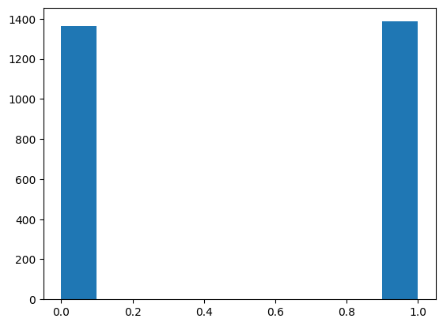

```python
plt.hist(df['sentiment'])
plt.show()
```

No null values and the distribution is roughly even.

To search for unusual characters, the following function is created to produce a list of character and a list of words:

```python
# Creates a list of unique characters 'list_of_chars' and list of unique words 'word_bag' from input 'reviews'
def char_word_bags(reviews=df['review'], display=False):
    list_of_chars = []
    word_bag = []
    for comment in reviews:
        for character in comment:
            if character not in list_of_chars:
                list_of_chars.append(character)
    if display:
        print(list_of_chars)

    for revw in reviews:
        for word in revw.split(" "):
            if word not in word_bag:
                word_bag.append(word)
    if display:
        print(word_bag)

    return list_of_chars, word_bag


raw_char_list, raw_word_bag = char_word_bags(df['review'], False)
print(f"\nList of unique characters (before processing):\n{raw_char_list}\n")
print(f"\nList of unique words (before processing):\n{raw_word_bag}\n")
```

```
List of unique characters (before processing):
['S', 'o', ' ', 't', 'h', 'e', 'r', 'i', 's', 'n', 'w', 'a', 'y', 'f', 'm', 'p', 'l', 'u', 'g', 'U', 'I', 'b', 'c', 'v', '.', 'G', 'd', ',', 'E', 'x', 'j', 'T', '4', '5', 'M', 'A', 'J', 'O', 'R', 'P', 'B', 'L', '!', 'z', 'N', 'W', 'q', 'H', '+', 'V', '"', 'Y', 'D', 'F', 'k', "'", 'K', 'C', '/', '7',…


List of unique words (before processing):
['So', 'there', 'is', 'no', 'way', 'for', 'me', 'to', 'plug', 'it', 'in', 'here', 'the', 'US', 'unless', 'I', 'go', 'by', 'a', 'converter.', 'Good', 'case,', 'Excellent', 'value.', 'Great', 'jawbone.', 'Tied', 'charger', 'conversations', 'lasting', 'more', 'than', '45', 'minutes.MAJOR', 'PROBLEMS!!'…
```

There are a number of unusual characters that will need to be removed. The following uses regular expressions to remove punctuation, special characters, single character words, and instances of multiple spaces. Then it sets everything to lowercase, applies `word_tokenize` to split the sentence into words (and any remaining special characters), lemmatizes the words, and finally removes stop words such as "a", "me", "they", "our" that are of little value in determining sentiment. Then the split contents of the each review are restored with expected spacing between words.

```python
stop_words = stopwords.words('english')
description_list = []
raw_reviews = []
for description in df['review']:
    raw_reviews.append(description)
    #remove punctuation, special characters, single characters, and multiple spaces
    description = re.sub("[^a-zA-Z]", " ", description)
    description = re.sub("\s+[a-zA-Z]\s+", " ", description)
    description = re.sub("\s+", " ", description)

    #convert to lower case
    description = description.lower()

    # tokenization
    description = word_tokenize(description)

    # lemmatization
    lemma = WordNetLemmatizer()
    description = [lemma.lemmatize(word) for word in description]

    # removing stop words
    description = [word for word in description if not word in stop_words]
    description = " ".join(description)
    description_list.append(description)
```

Below are the stop words used:

```python
print(f"\nStop words:\n{stop_words}\n")
```

```
Stop words:
['i', 'me', 'my', 'myself', 'we', 'our', 'ours', 'ourselves', 'you', "you're", "you've", "you'll", "you'd", 'your', 'yours', 'yourself', 'yourselves', 'he', 'him', 'his', 'himself', 'she', "she's", 'her', 'hers', 'herself', 'it', "it's", 'its', 'itself', 'they', 'them', 'their', 'theirs', 'themselve…
```

The original reviews prior to being processed:

```python
print(f"\nOriginal reviews:\n{raw_reviews}\n")
```

```
Original reviews:
['So there is no way for me to plug it in here in the US unless I go by a converter.', 'Good case, Excellent value.', 'Great for the jawbone.', 'Tied to charger for conversations lasting more than 45 minutes.MAJOR PROBLEMS!!', 'The mic is great.', 'I have to jiggle the plug to get it to line up righ…
```

The reviews after being processed:

```python
print(f"\nCleaned reviews:\n{description_list}\n")
```

```
Cleaned reviews:
['way plug u unless go converter', 'good case excellent value', 'great jawbone', 'tied charger conversation lasting minute major problem', 'mic great', 'jiggle plug get line right get decent volume', 'several dozen several hundred contact imagine fun sending one one', 'razr owner must', 'needle say …
```

Verifying the sets of unique characters and words after processing:

```python
clean_char_list, clean_word_bag = char_word_bags(description_list, False)
print(f"List of unique characters (after processing):\n{clean_char_list}\n")
print(f"Length of above list (expecting 26 letters and 1 space): {len(clean_char_list)}\n")
print(f"List of unique words (after processing):\n{clean_word_bag}\n")
```

```
List of unique characters (after processing):
['w', 'a', 'y', ' ', 'p', 'l', 'u', 'g', 'n', 'e', 's', 'o', 'c', 'v', 'r', 't', 'd', 'x', 'j', 'b', 'i', 'h', 'm', 'z', 'f', 'q', 'k']

Length of above list (expecting 26 letters and 1 space): 27

List of unique words (after processing):
['way', 'plug', 'u', 'unless', 'go', 'converter', 'good', 'case', 'excellent', 'value', 'great', 'jawbone', 'tied', 'charger', 'conversation', 'lasting', 'minute', 'major', 'problem', 'mic', 'jiggle', 'get', 'line', 'right', 'decent', 'volume', 'several', 'dozen', 'hundred', 'contact', 'imagine', 'f…
```

The vocabulary size is computed using tokenization:

```python
# Tokenizing
tokens = Tokenizer()
tokens.fit_on_texts(df['review'])
vocab_size = len(tokens.word_index) + 1
max_sequence_embedding = int(np.sqrt(np.sqrt(vocab_size)) // 1 + 1)

print(f"Vocabulary size: {vocab_size}\n")
print(f"Embedding length (vocab_size^(1/4) (rounded up to nearest integer)): {max_sequence_embedding}\n")
print(f"Word index:\n{tokens.word_index}\n")
```

```
Vocabulary size: 5272

Embedding length (vocab_size^(1/4) (rounded up to nearest integer)): 9

Word index:
{'the': 1, 'and': 2, 'i': 3, 'a': 4, 'is': 5, 'it': 6, 'to': 7, 'this': 8, 'of': 9, 'was': 10, 'in': 11, 'for': 12, 'not': 13, 'that': 14, 'with': 15, 'my': 16, 'very': 17, 'good': 18, 'on': 19, 'great': 20, 'you': 21, 'but': 22, 'have': 23, 'movie': 24, 'are': 25, 'as': 26, 'so': 27, 'phone': 28, '…
```

Using the original reviews in `df['review']`, there are 5271 unique words present in the dataset's vocabulary, with the vocabulary size being set as 5272 to accommodate special use cases reserving index 0 when building the model.

As discussed in Dr. Elleh's presentation (Elleh, 2024 [1]), word embedding lengths can be initially calculated as the fourth root of the vocabulary size, which rounds up to 9 for this dataset. The usual suggestion for language processing is between 100 and 300, but as will be demonstrated in the following sections, increasing it to that level had no measurable improvement on model accuracy and led to increased training times. Additional data that considerably increases the (processed) vocabulary size would need to consider a higher embedding length, but for the purposes of this project using an embedding length of 9 is adequate (as the models don't improve with higher embedding lengths).

For the maximum sequence length to be used, the review lengths (in words) are calculated and placed in the array `review_length`. An initial threshold of `long_rev_thresh = 50` is used to isolate longer reviews to avoid a skewed and unhelpful histogram. The mean, median, maximum, and minimum review lengths are also determined.

```python
# Finding min, median, mean, and max lengths of reviews. Also creating arrays for reviews of length over long_rev_thresh.
long_rev_thresh = 50
long_rev_text = []
review_length = []
for rev in df['review']:
    rev_length = len(rev.split(" "))
    review_length.append(rev_length)
    if rev_length > long_rev_thresh:
        long_rev_text.append(rev)

review_max = np.max(review_length)
review_mean = np.mean(review_length)
review_median = np.median(review_length)
review_min = np.min(review_length)
print(f"Maximum review length (words): {review_max}\n")
print(f"Mean review length (words): {round(review_mean, 2)}\n")
print(f"Median review length (words): {review_median}\n")
print(f"Minimum review length (words): {review_min}\n")
```

```
Maximum review length (words): 1393

Mean review length (words): 13.55

Median review length (words): 11.0

Minimum review length (words): 1
```

Looking at the number of long reviews over 50 words:

```python
print(f"There are {len(long_rev_text)} reviews above {long_rev_thresh} characters:\n{long_rev_text}\n")
```

```
There are 11 reviews above 50 characters:
[' The structure of this film is easily the most tightly constructed in the history of cinema.  \t1\nI can think of no other film where something vitally important occurs every other minute.  \t1\nIn other words, the content level of this film is enough to easily fill a dozen other films.  \t1\nHow …
```

Of the 2748 reviews, this is an extremely small number. The reviews appear legitimate, just long-winded. They don't need to be removed, but considering how few reviews have more than 50 words, there's little justification in keeping a maximum sequence length to retain all of the words in even the largest reviews. Looking at histograms:

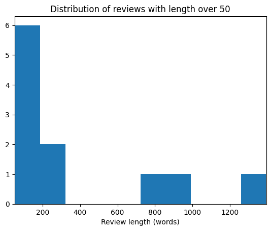

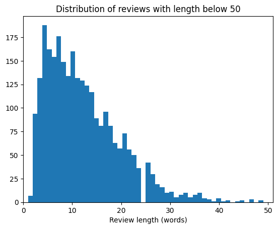

```python
hist_review_lengths = np.array(review_length)

plt.hist(hist_review_lengths[hist_review_lengths >= long_rev_thresh])
plt.xlim(long_rev_thresh, review_max + 1)
plt.xlabel('Review length (words)')
plt.title(f'Distribution of reviews with length over {long_rev_thresh}')
plt.show()

plt.hist(hist_review_lengths[hist_review_lengths < long_rev_thresh], bins=long_rev_thresh)
plt.xlim(0, long_rev_thresh + 1)
plt.xlabel('Review length (words)')
plt.title(f'Distribution of reviews with length below {long_rev_thresh}')
plt.show()
```

From the above, a cutoff of 30 or 40 looks reasonable, but as will be demonstrated, the models performed best with a maximum sequence length of 50. A maximum sequence length set to the maximum review length (1393) created models that were little better than random chance predictions. Using a limit of 50 words (compared to 40 or a lower value) has the additional benefit of preserving all (processed) reviews with the exception of 11 of them that are truncated to the first 50 words.

B.2. Tokenization

Tokenization separates the input text into smaller sequences (tokens), which can be words, characters, or segments of words (Elleh, 2024 [1]). These tokens are then assigned an index in the tokenizer's `word_index`, simplifying the model's internal processing and representations as integers over strings of arbitrary length. In general, tokenization also involves processing the text by removing unusual or unwanted characters (such as punctuation), removing stop words, performing stemming or lemmatization, creating N-grams, padding, and truncating.

In this project, the raw data was first processed then tokenized (by individual word) earlier in the previous section. Tokenizing required `Tokenizer` from `tensorflow.keras.preprocessing.text` while the other processing steps used `re`, `pandas` (as `df['review']` was referenced), `stopwords` from `nltk.corpus`, and `word_tokenize` and `WordNetLemmatizer` from `nltk`. Below is the code previously applied:

```python
#import pandas as pd
#import re
#from tensorflow.keras.preprocessing.text import Tokenizer
#from nltk import word_tokenize, WordNetLemmatizer
#from nltk.corpus import stopwords


# Processing data before tokenizing
stop_words = stopwords.words('english')
description_list = []
raw_reviews = []
for description in df['review']:
    raw_reviews.append(description)
    #remove punctuation, special characters, single characters, and multiple spaces
    description = re.sub("[^a-zA-Z]", " ", description)
    description = re.sub("\s+[a-zA-Z]\s+", " ", description)
    description = re.sub("\s+", " ", description)

    #convert to lower case
    description = description.lower()

    # tokenization
    description = word_tokenize(description)

    # lemmatization
    lemma = WordNetLemmatizer()
    description = [lemma.lemmatize(word) for word in description]

    # removing stop words
    description = [word for word in description if not word in stop_words]
    description = " ".join(description)
    description_list.append(description)


# Tokenizing
tokens = Tokenizer()
tokens.fit_on_texts(df['review'])
vocab_size = len(tokens.word_index) + 1
max_sequence_embedding = int(np.sqrt(np.sqrt(vocab_size)) // 1 + 1)

print(f"Vocabulary size: {vocab_size}\n")
print(f"Embedding length (vocab_size^(1/4) (rounded up to nearest integer)): {max_sequence_embedding}\n")
print(f"Word index:\n{tokenizer.word_index}\n")
```

[output not shown]

B.3. Padding process

Padding enforces consistency in the lengths of the input data to a neural network by padding 0s to inputs with lengths below the maximum threshold, while data with lengths above the maximum threshold are truncated to be the desired size. This standardization procedure pads to the left ('pre') or to the right ('post'), with analogous options for truncation.

For this project, manually inspecting the reviews of length greater than 50 words show the sentiments are still captured within the first 50 words, so applying 'post' truncation is appropriate. Padding is also applied as 'post' for consistency with truncation and to maintain training and test data with the relevant, non-padded parts of their inputs at their fronts.

See below:

```python
# Splits data into training and test sets then pads according to 'max_padding_length', with padding and truncating both occuring 'post'.
def pad_split(max_padding_length, save=False):
    X = np.array(description_list)
    y = df['sentiment'].values

    # Setting random seeds
    rd = 40
    tf_random.set_seed(16)

    X_train, X_test, y_train, y_test = train_test_split(X, y, test_size=0.20, random_state=rd, stratify=y)

    y_train = pd.Series(y_train)
    y_test = pd.Series(y_test)

    print(f"Training size and testing size: {X_train.shape}, {X_test.shape}\n")

    max_length_pad = max_padding_length
    padding_type = 'post'
    trunc_type = 'post'

    sequences_train = tokens.texts_to_sequences(X_train)
    padded_train = pad_sequences(sequences_train, maxlen=max_length_pad, padding=padding_type, truncating=trunc_type)

    sequences_test = tokens.texts_to_sequences(X_test)
    padded_test = pad_sequences(sequences_test, maxlen=max_length_pad, padding=padding_type, truncating=trunc_type)

    training_padded = np.array(padded_train)
    training_label = np.array(y_train)
    test_padded = np.array(padded_test)
    test_label = np.array(y_test)

    if save:
        pd.DataFrame(training_padded).to_csv("training_padded.csv")
        pd.DataFrame(training_label).to_csv("training_label.csv")
        pd.DataFrame(test_padded).to_csv("test_padded.csv")
        pd.DataFrame(test_label).to_csv("test_label.csv")

    return X_train, X_test, y_train, y_test, training_padded, training_label, test_padded, test_label

X_train, X_test, y_train, y_test, training_padded, training_label, test_padded, test_label = pad_split(50, False)
```

```
Training size and testing size: (2198,), (550,)
```

An example of one of the padded sequences:

```python
print(training_padded[15])
```

```
[  49  219  175  278 3399 1885 1886  781  206 5254 1887 3400 3401  541
  340    0    0    0    0    0    0    0    0    0    0    0    0    0
    0    0    0    0    0    0    0    0    0    0    0    0    0    0
    0    0    0    0    0    0    0    0]
```

B.4. Categories of sentiment

As displayed in section B.1., there are two categories of sentiment values: 0 ("Negative") and 1 ("Positive).

B.5. Steps to prepare the data

The data is prepared by doing the following:

1. Data is read from the three csv files (Amazon, IMDB, and Yelp) into their own dataframe. They're then concatenated into a single dataframe.
2. A histogram of the `sentiment` values find the classes are balanced.
3. No nulls are found by using `df.isnull().sum()`.
4. The function `char_word_bags` creates sets of unique characters and words for initial inspection prior to processing and verifying the future processing meets expectations (e.g. no special characters remaining).
5. The data is processed first through regular expression substitution that removes punctuation, special characters, single characters, and multiple spaces in each review. All remaining characters are then converted to lowercase.
6. `word_tokenize` is applied to each review to split it into constituent words within an array that are then lemmatized to a root form (lemma) with `WordNetLemmatizer`. Finally, stop words are removed from each review and the array of words is restored to a single string for each review. `char_word_bags` is applied again to verify the data is processed as needed.
7. Tokenization is applied to the original reviews in `df['review']` to ensure the vocabulary created contains all valid (e.g. no special characters) words when the processed data is later split. This creates a `word_index`, vocabulary size, and an estimate of an embedding length as the fourth root of the vocabulary size.
8. The lengths of the reviews in words are examined, finding the minimum, mean, median, and maximum. After reviewing histograms, it's determined a threshold of 50 for maximum sequence length when padding is optimal.
9. The cleaned reviews and their sentiment values are loaded and split into training and test sets, following the standard convention of 80% training and 20% testing, stratified by the sentiment classes. The reviews in the training and test sets are then vectorized by applying `texts_to_sequences` from the previously created tokenizer.
10. Padding and truncation are performed (both in 'post') to the newly created sequences of training and test data, ensuring they have a standardized length of `max_padding_length = 50`. The cleaned data sets and their labels are saved to csv files for later use.
11. The validation split occurs later when the RNN is compiled and fit to the data, splitting the (initial) training data as 70% training and 30% validation.

B.6 Prepared data set

See the attached files "training_padded.csv", "training_label.csv", "test_padded.csv", and "test_label.csv".

C.1. Model summary

Below are the functions used to create the RNN models and evaluate them:

```python
# Creates RNN with an embedding layer determined by 'vocabulary' and 'embedding_dim', then uses a GlobalAveragePooling1D layer, and two dense layers.
# The first dense layer has nodes 'nodes' (using 'relu') and the second uses the activation function 'activation'.
def model_creation(nodes=128, vocabulary=vocab_size, embedding_dim=max_sequence_embedding, activation='sigmoid'):
    model = Sequential([
        Embedding(input_dim=vocabulary, output_dim=embedding_dim),
        GlobalAveragePooling1D(),
        Dense(nodes, activation='relu'),
        Dense(2, activation=activation)
    ])
    return model


# Creates RNN with an embedding layer determined by 'vocabulary' and 'embedding_dim', then uses a GlobalAveragePooling1D layer, and three dense layers.
# The first dense layer has nodes 'nodes', the second has nodes 'nodes//2' (both use 'relu'), and the third uses the activation function 'activation'.
def model_creation_3Dense(nodes=128, vocabulary=vocab_size, embedding_dim=max_sequence_embedding, activation='sigmoid'):
    model = Sequential([
        Embedding(input_dim=vocabulary, output_dim=embedding_dim),
        GlobalAveragePooling1D(),
        Dense(nodes, activation='relu'),
        Dense(nodes//2, activation='relu'),
        Dense(2, activation=activation)
    ])
    return model


# Plot the metric (such as accuracy or loss) and its validation score vs epoch
def plot_graphs(history, metric):
    plt.plot(history.history[metric])
    plt.plot(history.history['val_'+metric])
    plt.xlabel("Epoch")
    plt.ylabel(metric)
    plt.legend([metric, 'val_'+metric])
    plt.show()
    return


# Compiles and fits RNN model and provides model evaluation/summary measures on training and test data with predictions
def model_eval(model, train_pad=training_padded, train_labels=training_label, test_pad=test_padded, test_labels=test_label, X_tst=X_test, y_tst=y_test,
               loss='sparse_categorical_crossentropy', optimizer='adam', metrics=['accuracy'], batch_size=16, num_epochs=20, patience=10):
    validation_splitting = 0.3
    shfl = True
    vrbs = True
    test_index = np.random.randint(0, len(X_tst))

    model.compile(loss=loss, optimizer=optimizer, metrics=metrics)
    history = model.fit(train_pad, train_labels, batch_size=batch_size, epochs=num_epochs, validation_split=validation_splitting, shuffle=shfl,
                        callbacks=[EarlyStopping(patience=patience)], verbose=vrbs)
    print(model.summary())

    predictions_tr = model.predict(train_pad)
    predictions_te = model.predict(test_pad)

    print(f"\nText of review at index {test_index} to be predicted:\n{X_tst[test_index]}\n")
    print(f"Predicted: {'Negative' if predictions_te[test_index][0] >= 0.5 else 'Positive'} review\n")
    print(f"Actual: {'Negative' if y_tst[test_index] == 0 else 'Positive'} review\n")

    score_tr = model.evaluate(train_pad, train_labels, verbose=0)
    print(f"Training loss: {score_tr[0]} / Training accuracy: {score_tr[1]}")

    score_te = model.evaluate(test_pad, test_labels, verbose=0)
    print(f"Test loss: {score_te[0]} / Test accuracy: {score_te[1]}")

    predictions_te_converted = np.apply_along_axis(lambda x: 0 if x[0] >= 0.4999999 else 1, 1, predictions_te)
    cnfs_mtx = confusion_matrix(test_labels, predictions_te_converted)
    print(f"\nConfusion matrix on test data vs predictions:\n{cnfs_mtx}\n")

    plot_graphs(history, metrics[0])
    plot_graphs(history, "loss")
    return
```

Comparisons with other models to justify the choices of layers and parameters will be done in sections C.2. and C.3. The best performing model found was a sequential RNN with:

- data padded/truncated to a maximum length of 50
- an embedding layer with a word embedding length of 9 as the output dimension and an input dimension of the vocabulary size `vocab_size = 5272`
- a 1D GlobalAveragePooling layer
- a dense layer with 128 nodes and activation function `relu`
- an output dense layer of 2 nodes with activation function `sigmoid`
- loss function `sparse_categorical_crossentropy`
- optimizer function `adam`
- `batch_size = 16`
- 20 epochs
- patience of 10 epochs for an early stopping criterion

Below is the final model's output summary and evaluation:

```python
X_train, X_test, y_train, y_test, training_padded, training_label, test_padded, test_label = pad_split(50, False)
model0 = model_creation()
model_eval(model0)
```

[output not shown]

```
Training size and testing size: (2198,), (550,)

97/97 ━━━━━━━━━━━━━━━━━━━━ 2s 4ms/step - accuracy: 0.5047 - loss: 0.6935 - val_accuracy: 0.4864 - val_loss: 0.6943
97/97 ━━━━━━━━━━━━━━━━━━━━ 0s 3ms/step - accuracy: 0.5174 - loss: 0.6927 - val_accuracy: 0.4864 - val_loss: 0.6935
97/97 ━━━━━━━━━━━━━━━━━━━━ 0s 3ms/step - accuracy: 0.5200 - loss: 0.6915 - val_accuracy: 0.4985 - val_loss: 0.6891
97/97 ━━━━━━━━━━━━━━━━━━━━ 0s 2ms/step - accuracy: 0.5788 - loss: 0.6831 - val_accuracy: 0.7652 - val_loss: 0.6738
97/97 ━━━━━━━━━━━━━━━━━━━━ 0s 2ms/step - accuracy: 0.6756 - loss: 0.6466 - val_accuracy: 0.7212 - val_loss: 0.6071
97/97 ━━━━━━━━━━━━━━━━━━━━ 0s 3ms/step - accuracy: 0.7658 - loss: 0.5421 - val_accuracy: 0.6273 - val_loss: 0.6349
97/97 ━━━━━━━━━━━━━━━━━━━━ 0s 2ms/step - accuracy: 0.7787 - loss: 0.4560 - val_accuracy: 0.6652 - val_loss: 0.6286
97/97 ━━━━━━━━━━━━━━━━━━━━ 0s 2ms/step - accuracy: 0.8306 - loss: 0.3750 - val_accuracy: 0.6833 - val_loss: 0.6521
97/97 ━━━━━━━━━━━━━━━━━━━━ 0s 3ms/step - accuracy: 0.8560 - loss: 0.3224 - val_accuracy: 0.6818 - val_loss: 0.6972
97/97 ━━━━━━━━━━━━━━━━━━━━ 0s 2ms/step - accuracy: 0.8759 - loss: 0.2902 - val_accuracy: 0.6833 - val_loss: 0.7180
97/97 ━━━━━━━━━━━━━━━━━━━━ 0s 2ms/step - accuracy: 0.8934 - loss: 0.2638 - val_accuracy: 0.7030 - val_loss: 0.7004
97/97 ━━━━━━━━━━━━━━━━━━━━ 0s 2ms/step - accuracy: 0.9152 - loss: 0.2357 - val_accuracy: 0.7182 - val_loss: 0.6588
97/97 ━━━━━━━━━━━━━━━━━━━━ 0s 3ms/step - accuracy: 0.9235 - loss: 0.2036 - val_accuracy: 0.7318 - val_loss: 0.6163
97/97 ━━━━━━━━━━━━━━━━━━━━ 0s 2ms/step - accuracy: 0.9343 - loss: 0.1726 - val_accuracy: 0.7364 - val_loss: 0.5818
97/97 ━━━━━━━━━━━━━━━━━━━━ 0s 2ms/step - accuracy: 0.9532 - loss: 0.1472 - val_accuracy: 0.7485 - val_loss: 0.5602
97/97 ━━━━━━━━━━━━━━━━━━━━ 0s 2ms/step - accuracy: 0.9633 - loss: 0.1283 - val_accuracy: 0.7667 - val_loss: 0.5525
97/97 ━━━━━━━━━━━━━━━━━━━━ 0s 2ms/step - accuracy: 0.9660 - loss: 0.1148 - val_accuracy: 0.7712 - val_loss: 0.5561
97/97 ━━━━━━━━━━━━━━━━━━━━ 0s 2ms/step - accuracy: 0.9660 - loss: 0.1049 - val_accuracy: 0.7727 - val_loss: 0.5664
97/97 ━━━━━━━━━━━━━━━━━━━━ 0s 2ms/step - accuracy: 0.9674 - loss: 0.0971 - val_accuracy: 0.7742 - val_loss: 0.5803
97/97 ━━━━━━━━━━━━━━━━━━━━ 0s 2ms/step - accuracy: 0.9670 - loss: 0.0911 - val_accuracy: 0.7758 - val_loss: 0.5965
```

```
Model: "sequential_77"
```

```
┏━━━━━━━━━━━━━━━━━━━━━━━━━━━━━━━━━━━━━━┳━━━━━━━━━━━━━━━━━━━━━━━━━━━━━┳━━━━━━━━━━━━━━━━━┓
┃ Layer (type)                         ┃ Output Shape                ┃         Param # ┃
┡━━━━━━━━━━━━━━━━━━━━━━━━━━━━━━━━━━━━━━╇━━━━━━━━━━━━━━━━━━━━━━━━━━━━━╇━━━━━━━━━━━━━━━━━┩
│ embedding_77 (Embedding)             │ (None, 50, 9)               │          47,448 │
├──────────────────────────────────────┼─────────────────────────────┼─────────────────┤
│ global_average_pooling1d_77          │ (None, 9)                   │               0 │
│ (GlobalAveragePooling1D)             │                             │                 │
├──────────────────────────────────────┼─────────────────────────────┼─────────────────┤
│ dense_160 (Dense)                    │ (None, 128)                 │           1,280 │
├──────────────────────────────────────┼─────────────────────────────┼─────────────────┤
│ dense_161 (Dense)                    │ (None, 2)                   │             258 │
└──────────────────────────────────────┴─────────────────────────────┴─────────────────┘
```

```
 Total params: 146,960 (574.07 KB)
```

```
 Trainable params: 48,986 (191.35 KB)
```

```
 Non-trainable params: 0 (0.00 B)
```

```
 Optimizer params: 97,974 (382.71 KB)
```

```
None
69/69 ━━━━━━━━━━━━━━━━━━━━ 0s 1ms/step
18/18 ━━━━━━━━━━━━━━━━━━━━ 0s 823us/step

Text of review at index 82 to be predicted:
take business dinner dollar elsewhere

Predicted: Negative review

Actual: Negative review

Training loss: 0.23992300033569336 / Training accuracy: 0.9126478433609009
Test loss: 0.6005603671073914 / Test accuracy: 0.7818182110786438

Confusion matrix on test data vs predictions:
[[225  48]
 [ 66 211]]
```

C.2. Network architecture

Adding an additional dense layer didn't provide statistically significant improvements. It was virtually the same albeit with a less desirable loss function.

```
97/97 ━━━━━━━━━━━━━━━━━━━━ 1s 3ms/step - accuracy: 0.5141 - loss: 0.6937 - val_accuracy: 0.4864 - val_loss: 0.6934
97/97 ━━━━━━━━━━━━━━━━━━━━ 0s 2ms/step - accuracy: 0.5148 - loss: 0.6928 - val_accuracy: 0.4864 - val_loss: 0.6931
97/97 ━━━━━━━━━━━━━━━━━━━━ 0s 2ms/step - accuracy: 0.5199 - loss: 0.6917 - val_accuracy: 0.4864 - val_loss: 0.6915
97/97 ━━━━━━━━━━━━━━━━━━━━ 0s 2ms/step - accuracy: 0.5731 - loss: 0.6774 - val_accuracy: 0.6894 - val_loss: 0.6363
97/97 ━━━━━━━━━━━━━━━━━━━━ 0s 2ms/step - accuracy: 0.6935 - loss: 0.5908 - val_accuracy: 0.7167 - val_loss: 0.5470
97/97 ━━━━━━━━━━━━━━━━━━━━ 0s 2ms/step - accuracy: 0.8315 - loss: 0.3989 - val_accuracy: 0.6864 - val_loss: 0.6669
97/97 ━━━━━━━━━━━━━━━━━━━━ 0s 2ms/step - accuracy: 0.8597 - loss: 0.3176 - val_accuracy: 0.7788 - val_loss: 0.4845
97/97 ━━━━━━━━━━━━━━━━━━━━ 0s 2ms/step - accuracy: 0.9358 - loss: 0.2175 - val_accuracy: 0.7318 - val_loss: 0.5420
97/97 ━━━━━━━━━━━━━━━━━━━━ 0s 2ms/step - accuracy: 0.8952 - loss: 0.2588 - val_accuracy: 0.6136 - val_loss: 0.9933
97/97 ━━━━━━━━━━━━━━━━━━━━ 0s 2ms/step - accuracy: 0.8271 - loss: 0.3883 - val_accuracy: 0.6545 - val_loss: 0.9063
97/97 ━━━━━━━━━━━━━━━━━━━━ 0s 2ms/step - accuracy: 0.8755 - loss: 0.3056 - val_accuracy: 0.6803 - val_loss: 0.9042
97/97 ━━━━━━━━━━━━━━━━━━━━ 0s 2ms/step - accuracy: 0.8862 - loss: 0.2831 - val_accuracy: 0.7000 - val_loss: 0.8350
97/97 ━━━━━━━━━━━━━━━━━━━━ 0s 2ms/step - accuracy: 0.8939 - loss: 0.2604 - val_accuracy: 0.7258 - val_loss: 0.6917
97/97 ━━━━━━━━━━━━━━━━━━━━ 0s 2ms/step - accuracy: 0.9251 - loss: 0.1952 - val_accuracy: 0.7333 - val_loss: 0.6328
97/97 ━━━━━━━━━━━━━━━━━━━━ 0s 2ms/step - accuracy: 0.9484 - loss: 0.1454 - val_accuracy: 0.7364 - val_loss: 0.6269
97/97 ━━━━━━━━━━━━━━━━━━━━ 0s 2ms/step - accuracy: 0.9556 - loss: 0.1208 - val_accuracy: 0.7530 - val_loss: 0.6127
97/97 ━━━━━━━━━━━━━━━━━━━━ 0s 2ms/step - accuracy: 0.9627 - loss: 0.1065 - val_accuracy: 0.7712 - val_loss: 0.6013
```

```
Model: "sequential_78"
```

```
┏━━━━━━━━━━━━━━━━━━━━━━━━━━━━━━━━━━━━━━┳━━━━━━━━━━━━━━━━━━━━━━━━━━━━━┳━━━━━━━━━━━━━━━━━┓
┃ Layer (type)                         ┃ Output Shape                ┃         Param # ┃
┡━━━━━━━━━━━━━━━━━━━━━━━━━━━━━━━━━━━━━━╇━━━━━━━━━━━━━━━━━━━━━━━━━━━━━╇━━━━━━━━━━━━━━━━━┩
│ embedding_78 (Embedding)             │ (None, 50, 9)               │          47,448 │
├──────────────────────────────────────┼─────────────────────────────┼─────────────────┤
│ global_average_pooling1d_78          │ (None, 9)                   │               0 │
│ (GlobalAveragePooling1D)             │                             │                 │
├──────────────────────────────────────┼─────────────────────────────┼─────────────────┤
│ dense_162 (Dense)                    │ (None, 128)                 │           1,280 │
├──────────────────────────────────────┼─────────────────────────────┼─────────────────┤
│ dense_163 (Dense)                    │ (None, 64)                  │           8,256 │
├──────────────────────────────────────┼─────────────────────────────┼─────────────────┤
│ dense_164 (Dense)                    │ (None, 2)                   │             130 │
└──────────────────────────────────────┴─────────────────────────────┴─────────────────┘
```

```
 Total params: 171,344 (669.32 KB)
```

```
 Trainable params: 57,114 (223.10 KB)
```

```
 Non-trainable params: 0 (0.00 B)
```

```
 Optimizer params: 114,230 (446.21 KB)
```

```
None
69/69 ━━━━━━━━━━━━━━━━━━━━ 0s 1ms/step
18/18 ━━━━━━━━━━━━━━━━━━━━ 0s 765us/step

Text of review at index 306 to be predicted:
instead got bore fest whiny spoiled brat babysitting

Predicted: Positive review

Actual: Negative review

Training loss: 0.2469411939382553 / Training accuracy: 0.9085532426834106
Test loss: 0.6167521476745605 / Test accuracy: 0.7690908908843994

Confusion matrix on test data vs predictions:
[[224  49]
 [ 71 206]]
```

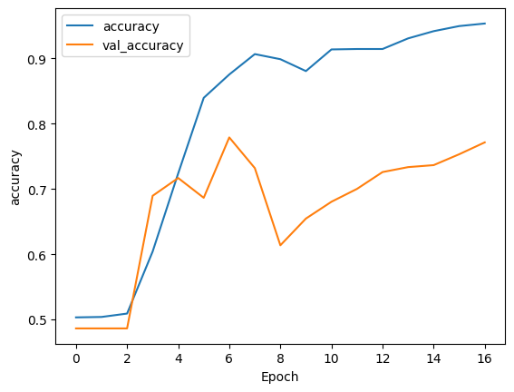

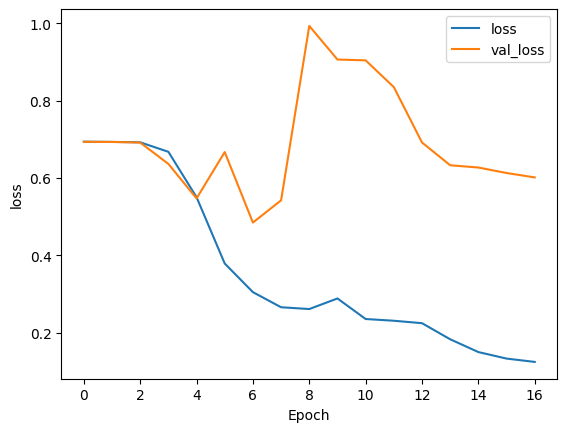

```python
model_dns = model_creation_3Dense()
model_eval(model_dns)
```

For the model described in section C.1., it's a sequential RNN using four layers with 48986 trainable parameters and 97974 optimizer parameters for a total of 146960 parameters.

C.3. Hyperparameters

As previously mentioned, the maximum input length of 50 needs to be justified. When the length is 30:

```python
# Using padding length of 30

X_train, X_test, y_train, y_test, training_padded, training_label, test_padded, test_label = pad_split(30, False)

# Compiles and fits RNN model and provides model evaluation/summary measures on training and test data with predictions
def model_eval(model, train_pad=training_padded, train_labels=training_label, test_pad=test_padded, test_labels=test_label, X_tst=X_test, y_tst=y_test,
               loss='sparse_categorical_crossentropy', optimizer='adam', metrics=['accuracy'], batch_size=16, num_epochs=20, patience=10):
    validation_splitting = 0.3
    shfl = True
    vrbs = True
    test_index = np.random.randint(0, len(X_tst))

    model.compile(loss=loss, optimizer=optimizer, metrics=metrics)
    history = model.fit(train_pad, train_labels, batch_size=batch_size, epochs=num_epochs, validation_split=validation_splitting, shuffle=shfl,
                        callbacks=[EarlyStopping(patience=patience)], verbose=vrbs)
    print(model.summary())

    predictions_tr = model.predict(train_pad)
    predictions_te = model.predict(test_pad)

    print(f"\nText of review at index {test_index} to be predicted:\n{X_tst[test_index]}\n")
    print(f"Predicted: {'Negative' if predictions_te[test_index][0] >= 0.5 else 'Positive'} review\n")
    print(f"Actual: {'Negative' if y_tst[test_index] == 0 else 'Positive'} review\n")

    score_tr = model.evaluate(train_pad, train_labels, verbose=0)
    print(f"Training loss: {score_tr[0]} / Training accuracy: {score_tr[1]}")

    score_te = model.evaluate(test_pad, test_labels, verbose=0)
    print(f"Test loss: {score_te[0]} / Test accuracy: {score_te[1]}")

    predictions_te_converted = np.apply_along_axis(lambda x: 0 if x[0] >= 0.4999999 else 1, 1, predictions_te)
    cnfs_mtx = confusion_matrix(test_labels, predictions_te_converted)
    print(f"\nConfusion matrix on test data vs predictions:\n{cnfs_mtx}\n")

    plot_graphs(history, metrics[0])
    plot_graphs(history, "loss")
    return
```

```
Training size and testing size: (2198,), (550,)
```

```
97/97 ━━━━━━━━━━━━━━━━━━━━ 1s 3ms/step - accuracy: 0.5184 - loss: 0.6933 - val_accuracy: 0.4864 - val_loss: 0.6934
97/97 ━━━━━━━━━━━━━━━━━━━━ 0s 2ms/step - accuracy: 0.5180 - loss: 0.6910 - val_accuracy: 0.7076 - val_loss: 0.6864
97/97 ━━━━━━━━━━━━━━━━━━━━ 0s 2ms/step - accuracy: 0.6612 - loss: 0.6755 - val_accuracy: 0.6197 - val_loss: 0.6556
97/97 ━━━━━━━━━━━━━━━━━━━━ 0s 2ms/step - accuracy: 0.7583 - loss: 0.5955 - val_accuracy: 0.7348 - val_loss: 0.5512
97/97 ━━━━━━━━━━━━━━━━━━━━ 0s 2ms/step - accuracy: 0.8669 - loss: 0.4275 - val_accuracy: 0.7030 - val_loss: 0.5640
97/97 ━━━━━━━━━━━━━━━━━━━━ 0s 2ms/step - accuracy: 0.8882 - loss: 0.3195 - val_accuracy: 0.7288 - val_loss: 0.5550
97/97 ━━━━━━━━━━━━━━━━━━━━ 0s 2ms/step - accuracy: 0.9214 - loss: 0.2439 - val_accuracy: 0.7455 - val_loss: 0.5553
97/97 ━━━━━━━━━━━━━━━━━━━━ 0s 2ms/step - accuracy: 0.9293 - loss: 0.1946 - val_accuracy: 0.7515 - val_loss: 0.5606
97/97 ━━━━━━━━━━━━━━━━━━━━ 0s 2ms/step - accuracy: 0.9484 - loss: 0.1598 - val_accuracy: 0.7409 - val_loss: 0.5746
97/97 ━━━━━━━━━━━━━━━━━━━━ 0s 2ms/step - accuracy: 0.9614 - loss: 0.1354 - val_accuracy: 0.7455 - val_loss: 0.6004
97/97 ━━━━━━━━━━━━━━━━━━━━ 0s 2ms/step - accuracy: 0.9659 - loss: 0.1181 - val_accuracy: 0.7439 - val_loss: 0.6405
97/97 ━━━━━━━━━━━━━━━━━━━━ 0s 2ms/step - accuracy: 0.9673 - loss: 0.1055 - val_accuracy: 0.7424 - val_loss: 0.6865
97/97 ━━━━━━━━━━━━━━━━━━━━ 0s 2ms/step - accuracy: 0.9693 - loss: 0.0954 - val_accuracy: 0.7409 - val_loss: 0.7297
97/97 ━━━━━━━━━━━━━━━━━━━━ 0s 2ms/step - accuracy: 0.9705 - loss: 0.0868 - val_accuracy: 0.7485 - val_loss: 0.7601
```

```
Model: "sequential_83"
```

```
┏━━━━━━━━━━━━━━━━━━━━━━━━━━━━━━━━━━━━━━┳━━━━━━━━━━━━━━━━━━━━━━━━━━━━━┳━━━━━━━━━━━━━━━━━┓
┃ Layer (type)                         ┃ Output Shape                ┃         Param # ┃
┡━━━━━━━━━━━━━━━━━━━━━━━━━━━━━━━━━━━━━━╇━━━━━━━━━━━━━━━━━━━━━━━━━━━━━╇━━━━━━━━━━━━━━━━━┩
│ embedding_83 (Embedding)             │ (None, 30, 9)               │          47,448 │
├──────────────────────────────────────┼─────────────────────────────┼─────────────────┤
│ global_average_pooling1d_83          │ (None, 9)                   │               0 │
│ (GlobalAveragePooling1D)             │                             │                 │
├──────────────────────────────────────┼─────────────────────────────┼─────────────────┤
│ dense_173 (Dense)                    │ (None, 128)                 │           1,280 │
├──────────────────────────────────────┼─────────────────────────────┼─────────────────┤
│ dense_174 (Dense)                    │ (None, 2)                   │             258 │
└──────────────────────────────────────┴─────────────────────────────┴─────────────────┘
```

```
 Total params: 146,960 (574.07 KB)
```

```
 Trainable params: 48,986 (191.35 KB)
```

```
 Non-trainable params: 0 (0.00 B)
```

```
 Optimizer params: 97,974 (382.71 KB)
```

```
None
69/69 ━━━━━━━━━━━━━━━━━━━━ 0s 1ms/step
18/18 ━━━━━━━━━━━━━━━━━━━━ 0s 765us/step

Text of review at index 156 to be predicted:
one thing hate mode set button side

Predicted: Negative review

Actual: Negative review

Training loss: 0.34488555788993835 / Training accuracy: 0.8726114630699158
Test loss: 0.7896615266799927 / Test accuracy: 0.7418181896209717

Confusion matrix on test data vs predictions:
[[253  20]
 [124 153]]
```

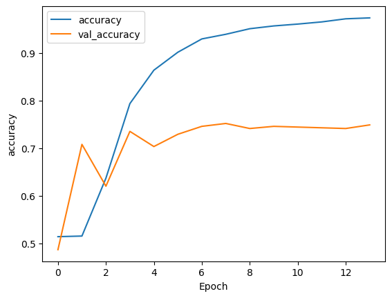

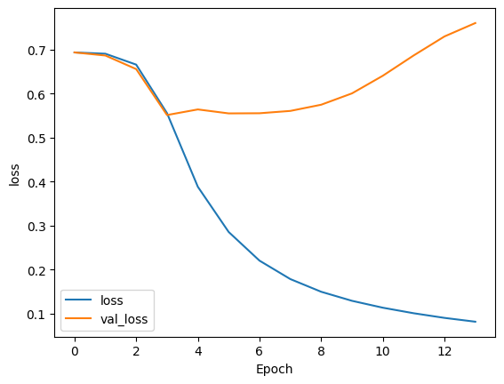

```python
model30 = model_creation()
model_eval(model30)
```

For a padding length of 40:

```python
# Using padding length of 40

X_train, X_test, y_train, y_test, training_padded, training_label, test_padded, test_label = pad_split(40, False)

# Compiles and fits RNN model and provides model evaluation/summary measures on training and test data with predictions
def model_eval(model, train_pad=training_padded, train_labels=training_label, test_pad=test_padded, test_labels=test_label, X_tst=X_test, y_tst=y_test,
               loss='sparse_categorical_crossentropy', optimizer='adam', metrics=['accuracy'], batch_size=16, num_epochs=20, patience=10):
    validation_splitting = 0.3
    shfl = True
    vrbs = True
    test_index = np.random.randint(0, len(X_tst))

    model.compile(loss=loss, optimizer=optimizer, metrics=metrics)
    history = model.fit(train_pad, train_labels, batch_size=batch_size, epochs=num_epochs, validation_split=validation_splitting, shuffle=shfl,
                        callbacks=[EarlyStopping(patience=patience)], verbose=vrbs)
    print(model.summary())

    predictions_tr = model.predict(train_pad)
    predictions_te = model.predict(test_pad)

    print(f"\nText of review at index {test_index} to be predicted:\n{X_tst[test_index]}\n")
    print(f"Predicted: {'Negative' if predictions_te[test_index][0] >= 0.5 else 'Positive'} review\n")
    print(f"Actual: {'Negative' if y_tst[test_index] == 0 else 'Positive'} review\n")

    score_tr = model.evaluate(train_pad, train_labels, verbose=0)
    print(f"Training loss: {score_tr[0]} / Training accuracy: {score_tr[1]}")

    score_te = model.evaluate(test_pad, test_labels, verbose=0)
    print(f"Test loss: {score_te[0]} / Test accuracy: {score_te[1]}")

    predictions_te_converted = np.apply_along_axis(lambda x: 0 if x[0] >= 0.4999999 else 1, 1, predictions_te)
    cnfs_mtx = confusion_matrix(test_labels, predictions_te_converted)
    print(f"\nConfusion matrix on test data vs predictions:\n{cnfs_mtx}\n")

    plot_graphs(history, metrics[0])
    plot_graphs(history, "loss")
    return
```

```
Training size and testing size: (2198,), (550,)
```

```
97/97 ━━━━━━━━━━━━━━━━━━━━ 1s 3ms/step - accuracy: 0.5047 - loss: 0.6934 - val_accuracy: 0.4864 - val_loss: 0.6937
97/97 ━━━━━━━━━━━━━━━━━━━━ 0s 2ms/step - accuracy: 0.5175 - loss: 0.6920 - val_accuracy: 0.4864 - val_loss: 0.6914
97/97 ━━━━━━━━━━━━━━━━━━━━ 0s 2ms/step - accuracy: 0.5504 - loss: 0.6844 - val_accuracy: 0.5879 - val_loss: 0.6737
97/97 ━━━━━━━━━━━━━━━━━━━━ 0s 2ms/step - accuracy: 0.6887 - loss: 0.6396 - val_accuracy: 0.7227 - val_loss: 0.5914
97/97 ━━━━━━━━━━━━━━━━━━━━ 0s 2ms/step - accuracy: 0.7993 - loss: 0.5073 - val_accuracy: 0.6530 - val_loss: 0.6219
97/97 ━━━━━━━━━━━━━━━━━━━━ 0s 2ms/step - accuracy: 0.8151 - loss: 0.4076 - val_accuracy: 0.6803 - val_loss: 0.6256
97/97 ━━━━━━━━━━━━━━━━━━━━ 0s 2ms/step - accuracy: 0.8587 - loss: 0.3300 - val_accuracy: 0.6970 - val_loss: 0.6260
97/97 ━━━━━━━━━━━━━━━━━━━━ 0s 2ms/step - accuracy: 0.9023 - loss: 0.2746 - val_accuracy: 0.7152 - val_loss: 0.6180
97/97 ━━━━━━━━━━━━━━━━━━━━ 0s 2ms/step - accuracy: 0.9224 - loss: 0.2315 - val_accuracy: 0.7303 - val_loss: 0.6031
97/97 ━━━━━━━━━━━━━━━━━━━━ 0s 2ms/step - accuracy: 0.9304 - loss: 0.1955 - val_accuracy: 0.7379 - val_loss: 0.5829
97/97 ━━━━━━━━━━━━━━━━━━━━ 0s 2ms/step - accuracy: 0.9376 - loss: 0.1647 - val_accuracy: 0.7409 - val_loss: 0.5650
97/97 ━━━━━━━━━━━━━━━━━━━━ 0s 2ms/step - accuracy: 0.9641 - loss: 0.1400 - val_accuracy: 0.7561 - val_loss: 0.5567
97/97 ━━━━━━━━━━━━━━━━━━━━ 0s 2ms/step - accuracy: 0.9677 - loss: 0.1219 - val_accuracy: 0.7667 - val_loss: 0.5592
97/97 ━━━━━━━━━━━━━━━━━━━━ 0s 2ms/step - accuracy: 0.9670 - loss: 0.1091 - val_accuracy: 0.7682 - val_loss: 0.5707
97/97 ━━━━━━━━━━━━━━━━━━━━ 0s 2ms/step - accuracy: 0.9651 - loss: 0.1002 - val_accuracy: 0.7697 - val_loss: 0.5890
97/97 ━━━━━━━━━━━━━━━━━━━━ 0s 2ms/step - accuracy: 0.9676 - loss: 0.0941 - val_accuracy: 0.7606 - val_loss: 0.6153
97/97 ━━━━━━━━━━━━━━━━━━━━ 0s 2ms/step - accuracy: 0.9715 - loss: 0.0901 - val_accuracy: 0.7561 - val_loss: 0.6548
97/97 ━━━━━━━━━━━━━━━━━━━━ 0s 2ms/step - accuracy: 0.9736 - loss: 0.0879 - val_accuracy: 0.7455 - val_loss: 0.7156
97/97 ━━━━━━━━━━━━━━━━━━━━ 0s 2ms/step - accuracy: 0.9717 - loss: 0.0872 - val_accuracy: 0.7424 - val_loss: 0.8028
97/97 ━━━━━━━━━━━━━━━━━━━━ 0s 2ms/step - accuracy: 0.9737 - loss: 0.0880 - val_accuracy: 0.7242 - val_loss: 0.9185
```

```
Model: "sequential_84"
```

```
┏━━━━━━━━━━━━━━━━━━━━━━━━━━━━━━━━━━━━━━┳━━━━━━━━━━━━━━━━━━━━━━━━━━━━━┳━━━━━━━━━━━━━━━━━┓
┃ Layer (type)                         ┃ Output Shape                ┃         Param # ┃
┡━━━━━━━━━━━━━━━━━━━━━━━━━━━━━━━━━━━━━━╇━━━━━━━━━━━━━━━━━━━━━━━━━━━━━╇━━━━━━━━━━━━━━━━━┩
│ embedding_84 (Embedding)             │ (None, 40, 9)               │          47,448 │
├──────────────────────────────────────┼─────────────────────────────┼─────────────────┤
│ global_average_pooling1d_84          │ (None, 9)                   │               0 │
│ (GlobalAveragePooling1D)             │                             │                 │
├──────────────────────────────────────┼─────────────────────────────┼─────────────────┤
│ dense_175 (Dense)                    │ (None, 128)                 │           1,280 │
├──────────────────────────────────────┼─────────────────────────────┼─────────────────┤
│ dense_176 (Dense)                    │ (None, 2)                   │             258 │
└──────────────────────────────────────┴─────────────────────────────┴─────────────────┘
```

```
 Total params: 146,960 (574.07 KB)
```

```
 Trainable params: 48,986 (191.35 KB)
```

```
 Non-trainable params: 0 (0.00 B)
```

```
 Optimizer params: 97,974 (382.71 KB)
```

```
None
69/69 ━━━━━━━━━━━━━━━━━━━━ 0s 1ms/step
18/18 ━━━━━━━━━━━━━━━━━━━━ 0s 765us/step

Text of review at index 379 to be predicted:
really impressive place closed

Predicted: Negative review

Actual: Negative review

Training loss: 0.43700727820396423 / Training accuracy: 0.8457688689231873
Test loss: 0.9432131052017212 / Test accuracy: 0.7127272486686707

Confusion matrix on test data vs predictions:
[[255  18]
 [141 136]]
```

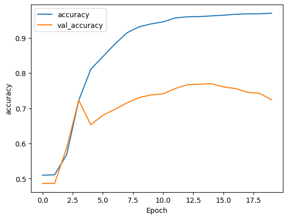

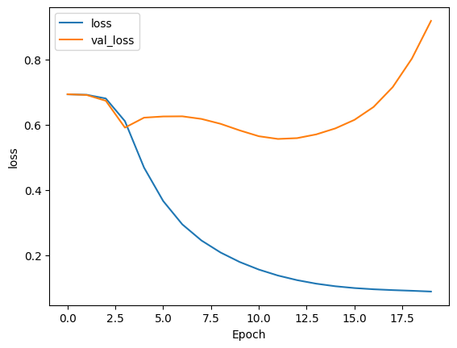

```python
model40 = model_creation()
model_eval(model40)
```

For a length of 60:

```python
# Using padding length of 60

X_train, X_test, y_train, y_test, training_padded, training_label, test_padded, test_label = pad_split(60, False)

# Compiles and fits RNN model and provides model evaluation/summary measures on training and test data with predictions
def model_eval(model, train_pad=training_padded, train_labels=training_label, test_pad=test_padded, test_labels=test_label, X_tst=X_test, y_tst=y_test,
               loss='sparse_categorical_crossentropy', optimizer='adam', metrics=['accuracy'], batch_size=16, num_epochs=20, patience=10):
    validation_splitting = 0.3
    shfl = True
    vrbs = True
    test_index = np.random.randint(0, len(X_tst))

    model.compile(loss=loss, optimizer=optimizer, metrics=metrics)
    history = model.fit(train_pad, train_labels, batch_size=batch_size, epochs=num_epochs, validation_split=validation_splitting, shuffle=shfl,
                        callbacks=[EarlyStopping(patience=patience)], verbose=vrbs)
    print(model.summary())

    predictions_tr = model.predict(train_pad)
    predictions_te = model.predict(test_pad)

    print(f"\nText of review at index {test_index} to be predicted:\n{X_tst[test_index]}\n")
    print(f"Predicted: {'Negative' if predictions_te[test_index][0] >= 0.5 else 'Positive'} review\n")
    print(f"Actual: {'Negative' if y_tst[test_index] == 0 else 'Positive'} review\n")

    score_tr = model.evaluate(train_pad, train_labels, verbose=0)
    print(f"Training loss: {score_tr[0]} / Training accuracy: {score_tr[1]}")

    score_te = model.evaluate(test_pad, test_labels, verbose=0)
    print(f"Test loss: {score_te[0]} / Test accuracy: {score_te[1]}")

    predictions_te_converted = np.apply_along_axis(lambda x: 0 if x[0] >= 0.4999999 else 1, 1, predictions_te)
    cnfs_mtx = confusion_matrix(test_labels, predictions_te_converted)
    print(f"\nConfusion matrix on test data vs predictions:\n{cnfs_mtx}\n")

    plot_graphs(history, metrics[0])
    plot_graphs(history, "loss")
    return
```

```
Training size and testing size: (2198,), (550,)
```

```
97/97 ━━━━━━━━━━━━━━━━━━━━ 1s 3ms/step - accuracy: 0.5047 - loss: 0.6937 - val_accuracy: 0.4864 - val_loss: 0.6940
97/97 ━━━━━━━━━━━━━━━━━━━━ 0s 2ms/step - accuracy: 0.5156 - loss: 0.6927 - val_accuracy: 0.4864 - val_loss: 0.6939
97/97 ━━━━━━━━━━━━━━━━━━━━ 0s 2ms/step - accuracy: 0.5152 - loss: 0.6922 - val_accuracy: 0.4864 - val_loss: 0.6926
97/97 ━━━━━━━━━━━━━━━━━━━━ 0s 2ms/step - accuracy: 0.5550 - loss: 0.6903 - val_accuracy: 0.4864 - val_loss: 0.6904
97/97 ━━━━━━━━━━━━━━━━━━━━ 0s 2ms/step - accuracy: 0.5650 - loss: 0.6816 - val_accuracy: 0.5803 - val_loss: 0.6784
97/97 ━━━━━━━━━━━━━━━━━━━━ 0s 2ms/step - accuracy: 0.6291 - loss: 0.6560 - val_accuracy: 0.7379 - val_loss: 0.6215
97/97 ━━━━━━━━━━━━━━━━━━━━ 0s 2ms/step - accuracy: 0.7456 - loss: 0.5701 - val_accuracy: 0.6000 - val_loss: 0.6489
97/97 ━━━━━━━━━━━━━━━━━━━━ 0s 2ms/step - accuracy: 0.7531 - loss: 0.5024 - val_accuracy: 0.6409 - val_loss: 0.6323
97/97 ━━━━━━━━━━━━━━━━━━━━ 0s 2ms/step - accuracy: 0.7917 - loss: 0.4231 - val_accuracy: 0.6788 - val_loss: 0.6191
97/97 ━━━━━━━━━━━━━━━━━━━━ 0s 2ms/step - accuracy: 0.8349 - loss: 0.3588 - val_accuracy: 0.6818 - val_loss: 0.6411
97/97 ━━━━━━━━━━━━━━━━━━━━ 0s 2ms/step - accuracy: 0.8482 - loss: 0.3177 - val_accuracy: 0.6818 - val_loss: 0.6955
97/97 ━━━━━━━━━━━━━━━━━━━━ 0s 2ms/step - accuracy: 0.8561 - loss: 0.2961 - val_accuracy: 0.6788 - val_loss: 0.7593
97/97 ━━━━━━━━━━━━━━━━━━━━ 0s 2ms/step - accuracy: 0.8721 - loss: 0.2852 - val_accuracy: 0.6788 - val_loss: 0.7945
97/97 ━━━━━━━━━━━━━━━━━━━━ 0s 2ms/step - accuracy: 0.8834 - loss: 0.2754 - val_accuracy: 0.6879 - val_loss: 0.7757
97/97 ━━━━━━━━━━━━━━━━━━━━ 0s 2ms/step - accuracy: 0.8852 - loss: 0.2578 - val_accuracy: 0.7076 - val_loss: 0.7135
97/97 ━━━━━━━━━━━━━━━━━━━━ 0s 2ms/step - accuracy: 0.9104 - loss: 0.2282 - val_accuracy: 0.7258 - val_loss: 0.6517
97/97 ━━━━━━━━━━━━━━━━━━━━ 0s 2ms/step - accuracy: 0.9246 - loss: 0.1955 - val_accuracy: 0.7303 - val_loss: 0.6087
97/97 ━━━━━━━━━━━━━━━━━━━━ 0s 2ms/step - accuracy: 0.9357 - loss: 0.1682 - val_accuracy: 0.7409 - val_loss: 0.5815
97/97 ━━━━━━━━━━━━━━━━━━━━ 0s 3ms/step - accuracy: 0.9534 - loss: 0.1471 - val_accuracy: 0.7439 - val_loss: 0.5652
97/97 ━━━━━━━━━━━━━━━━━━━━ 0s 2ms/step - accuracy: 0.9608 - loss: 0.1313 - val_accuracy: 0.7576 - val_loss: 0.5573
```

```
Model: "sequential_85"
```

```
┏━━━━━━━━━━━━━━━━━━━━━━━━━━━━━━━━━━━━━━┳━━━━━━━━━━━━━━━━━━━━━━━━━━━━━┳━━━━━━━━━━━━━━━━━┓
┃ Layer (type)                         ┃ Output Shape                ┃         Param # ┃
┡━━━━━━━━━━━━━━━━━━━━━━━━━━━━━━━━━━━━━━╇━━━━━━━━━━━━━━━━━━━━━━━━━━━━━╇━━━━━━━━━━━━━━━━━┩
│ embedding_85 (Embedding)             │ (None, 60, 9)               │          47,448 │
├──────────────────────────────────────┼─────────────────────────────┼─────────────────┤
│ global_average_pooling1d_85          │ (None, 9)                   │               0 │
│ (GlobalAveragePooling1D)             │                             │                 │
├──────────────────────────────────────┼─────────────────────────────┼─────────────────┤
│ dense_177 (Dense)                    │ (None, 128)                 │           1,280 │
├──────────────────────────────────────┼─────────────────────────────┼─────────────────┤
│ dense_178 (Dense)                    │ (None, 2)                   │             258 │
└──────────────────────────────────────┴─────────────────────────────┴─────────────────┘
```

```
 Total params: 146,960 (574.07 KB)
```

```
 Trainable params: 48,986 (191.35 KB)
```

```
 Non-trainable params: 0 (0.00 B)
```

```
 Optimizer params: 97,974 (382.71 KB)
```

```
None
69/69 ━━━━━━━━━━━━━━━━━━━━ 0s 1ms/step
18/18 ━━━━━━━━━━━━━━━━━━━━ 0s 824us/step

Text of review at index 41 to be predicted:
jalapeno bacon soooo good

Predicted: Positive review

Actual: Positive review

Training loss: 0.2584027051925659 / Training accuracy: 0.8903548717498779
Test loss: 0.5826421976089478 / Test accuracy: 0.7581818103790283

Confusion matrix on test data vs predictions:
[[243  30]
 [102 175]]
```

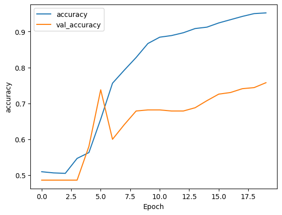

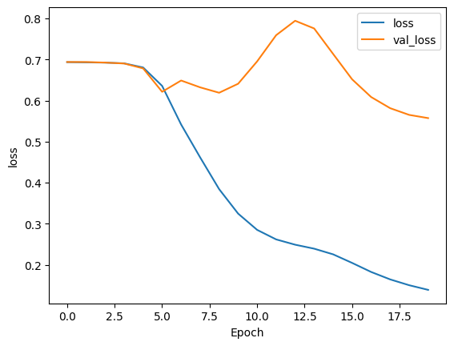

```python
model60 = model_creation()
model_eval(model60)
```

And trying 200:

```python
# Using padding length of 200

X_train, X_test, y_train, y_test, training_padded, training_label, test_padded, test_label = pad_split(200, False)

# Compiles and fits RNN model and provides model evaluation/summary measures on training and test data with predictions
def model_eval(model, train_pad=training_padded, train_labels=training_label, test_pad=test_padded, test_labels=test_label, X_tst=X_test, y_tst=y_test,
               loss='sparse_categorical_crossentropy', optimizer='adam', metrics=['accuracy'], batch_size=16, num_epochs=20, patience=10):
    validation_splitting = 0.3
    shfl = True
    vrbs = True
    test_index = np.random.randint(0, len(X_tst))

    model.compile(loss=loss, optimizer=optimizer, metrics=metrics)
    history = model.fit(train_pad, train_labels, batch_size=batch_size, epochs=num_epochs, validation_split=validation_splitting, shuffle=shfl,
                        callbacks=[EarlyStopping(patience=patience)], verbose=vrbs)
    print(model.summary())

    predictions_tr = model.predict(train_pad)
    predictions_te = model.predict(test_pad)

    print(f"\nText of review at index {test_index} to be predicted:\n{X_tst[test_index]}\n")
    print(f"Predicted: {'Negative' if predictions_te[test_index][0] >= 0.5 else 'Positive'} review\n")
    print(f"Actual: {'Negative' if y_tst[test_index] == 0 else 'Positive'} review\n")

    score_tr = model.evaluate(train_pad, train_labels, verbose=0)
    print(f"Training loss: {score_tr[0]} / Training accuracy: {score_tr[1]}")

    score_te = model.evaluate(test_pad, test_labels, verbose=0)
    print(f"Test loss: {score_te[0]} / Test accuracy: {score_te[1]}")

    predictions_te_converted = np.apply_along_axis(lambda x: 0 if x[0] >= 0.4999999 else 1, 1, predictions_te)
    cnfs_mtx = confusion_matrix(test_labels, predictions_te_converted)
    print(f"\nConfusion matrix on test data vs predictions:\n{cnfs_mtx}\n")

    plot_graphs(history, metrics[0])
    plot_graphs(history, "loss")
    return
```

```
Training size and testing size: (2198,), (550,)
```

```
97/97 ━━━━━━━━━━━━━━━━━━━━ 1s 3ms/step - accuracy: 0.4997 - loss: 0.6938 - val_accuracy: 0.4864 - val_loss: 0.6939
97/97 ━━━━━━━━━━━━━━━━━━━━ 0s 2ms/step - accuracy: 0.5123 - loss: 0.6932 - val_accuracy: 0.4864 - val_loss: 0.6942
97/97 ━━━━━━━━━━━━━━━━━━━━ 0s 2ms/step - accuracy: 0.5134 - loss: 0.6930 - val_accuracy: 0.4864 - val_loss: 0.6940
97/97 ━━━━━━━━━━━━━━━━━━━━ 0s 2ms/step - accuracy: 0.5179 - loss: 0.6929 - val_accuracy: 0.4864 - val_loss: 0.6941
97/97 ━━━━━━━━━━━━━━━━━━━━ 0s 2ms/step - accuracy: 0.5179 - loss: 0.6929 - val_accuracy: 0.4864 - val_loss: 0.6941
97/97 ━━━━━━━━━━━━━━━━━━━━ 0s 2ms/step - accuracy: 0.5179 - loss: 0.6929 - val_accuracy: 0.4864 - val_loss: 0.6942
97/97 ━━━━━━━━━━━━━━━━━━━━ 0s 2ms/step - accuracy: 0.5179 - loss: 0.6927 - val_accuracy: 0.4864 - val_loss: 0.6939
97/97 ━━━━━━━━━━━━━━━━━━━━ 0s 2ms/step - accuracy: 0.5152 - loss: 0.6928 - val_accuracy: 0.4864 - val_loss: 0.6941
97/97 ━━━━━━━━━━━━━━━━━━━━ 0s 2ms/step - accuracy: 0.5179 - loss: 0.6926 - val_accuracy: 0.4864 - val_loss: 0.6937
97/97 ━━━━━━━━━━━━━━━━━━━━ 0s 2ms/step - accuracy: 0.5125 - loss: 0.6926 - val_accuracy: 0.4864 - val_loss: 0.6940
97/97 ━━━━━━━━━━━━━━━━━━━━ 0s 2ms/step - accuracy: 0.5158 - loss: 0.6924 - val_accuracy: 0.4864 - val_loss: 0.6932
97/97 ━━━━━━━━━━━━━━━━━━━━ 0s 2ms/step - accuracy: 0.5159 - loss: 0.6924 - val_accuracy: 0.4864 - val_loss: 0.6940
97/97 ━━━━━━━━━━━━━━━━━━━━ 0s 2ms/step - accuracy: 0.5483 - loss: 0.6919 - val_accuracy: 0.4864 - val_loss: 0.6940
97/97 ━━━━━━━━━━━━━━━━━━━━ 0s 2ms/step - accuracy: 0.5185 - loss: 0.6917 - val_accuracy: 0.4864 - val_loss: 0.6939
97/97 ━━━━━━━━━━━━━━━━━━━━ 0s 2ms/step - accuracy: 0.5178 - loss: 0.6913 - val_accuracy: 0.4864 - val_loss: 0.6920
97/97 ━━━━━━━━━━━━━━━━━━━━ 0s 2ms/step - accuracy: 0.5338 - loss: 0.6910 - val_accuracy: 0.4864 - val_loss: 0.6923
97/97 ━━━━━━━━━━━━━━━━━━━━ 0s 2ms/step - accuracy: 0.5236 - loss: 0.6890 - val_accuracy: 0.4864 - val_loss: 0.6922
97/97 ━━━━━━━━━━━━━━━━━━━━ 0s 2ms/step - accuracy: 0.5342 - loss: 0.6874 - val_accuracy: 0.5227 - val_loss: 0.6901
97/97 ━━━━━━━━━━━━━━━━━━━━ 0s 2ms/step - accuracy: 0.5486 - loss: 0.6875 - val_accuracy: 0.4864 - val_loss: 0.6869
97/97 ━━━━━━━━━━━━━━━━━━━━ 0s 2ms/step - accuracy: 0.5807 - loss: 0.6748 - val_accuracy: 0.5121 - val_loss: 0.6745
```

```
Model: "sequential_87"
```

```
┏━━━━━━━━━━━━━━━━━━━━━━━━━━━━━━━━━━━━━━┳━━━━━━━━━━━━━━━━━━━━━━━━━━━━━┳━━━━━━━━━━━━━━━━━┓
┃ Layer (type)                         ┃ Output Shape                ┃         Param # ┃
┡━━━━━━━━━━━━━━━━━━━━━━━━━━━━━━━━━━━━━━╇━━━━━━━━━━━━━━━━━━━━━━━━━━━━━╇━━━━━━━━━━━━━━━━━┩
│ embedding_87 (Embedding)             │ (None, 200, 9)              │          47,448 │
├──────────────────────────────────────┼─────────────────────────────┼─────────────────┤
│ global_average_pooling1d_87          │ (None, 9)                   │               0 │
│ (GlobalAveragePooling1D)             │                             │                 │
├──────────────────────────────────────┼─────────────────────────────┼─────────────────┤
│ dense_181 (Dense)                    │ (None, 128)                 │           1,280 │
├──────────────────────────────────────┼─────────────────────────────┼─────────────────┤
│ dense_182 (Dense)                    │ (None, 2)                   │             258 │
└──────────────────────────────────────┴─────────────────────────────┴─────────────────┘
```

```
 Total params: 146,960 (574.07 KB)
```

```
 Trainable params: 48,986 (191.35 KB)
```

```
 Non-trainable params: 0 (0.00 B)
```

```
 Optimizer params: 97,974 (382.71 KB)
```

[output not shown]

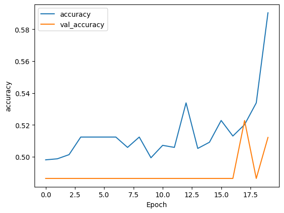

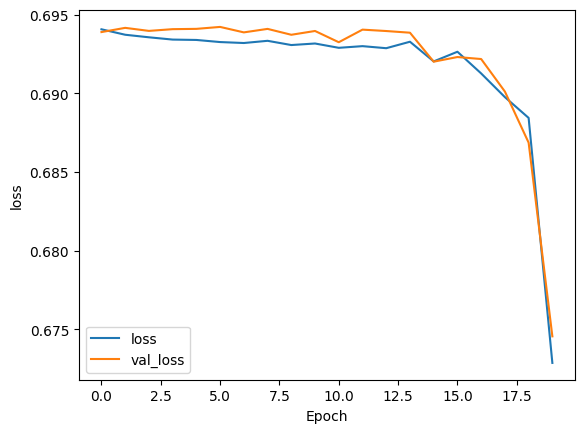

```python
model200 = model_creation()
model_eval(model200)
```

A padded length of 50 consistently performs the best, while attempting to go into the range of 200 to capture some of the longer reviews has abysmal accuracy that amounts to random selection.

The sentiment values are 0 and 1, so a binary classification task can be handled by using the `sigmoid` activation function (Elleh, 2024 [1]). However, to compare it with `softmax`:

```
Training size and testing size: (2198,), (550,)

97/97 ━━━━━━━━━━━━━━━━━━━━ 1s 5ms/step - accuracy: 0.5179 - loss: 0.6934 - val_accuracy: 0.4864 - val_loss: 0.6941
97/97 ━━━━━━━━━━━━━━━━━━━━ 0s 2ms/step - accuracy: 0.5159 - loss: 0.6925 - val_accuracy: 0.4864 - val_loss: 0.6923
97/97 ━━━━━━━━━━━━━━━━━━━━ 0s 2ms/step - accuracy: 0.5319 - loss: 0.6902 - val_accuracy: 0.7500 - val_loss: 0.6869
97/97 ━━━━━━━━━━━━━━━━━━━━ 0s 1ms/step - accuracy: 0.6703 - loss: 0.6800 - val_accuracy: 0.5848 - val_loss: 0.6731
97/97 ━━━━━━━━━━━━━━━━━━━━ 0s 2ms/step - accuracy: 0.6593 - loss: 0.6431 - val_accuracy: 0.7348 - val_loss: 0.6091
97/97 ━━━━━━━━━━━━━━━━━━━━ 0s 2ms/step - accuracy: 0.7786 - loss: 0.5417 - val_accuracy: 0.6273 - val_loss: 0.6349
97/97 ━━━━━━━━━━━━━━━━━━━━ 0s 2ms/step - accuracy: 0.7765 - loss: 0.4589 - val_accuracy: 0.6621 - val_loss: 0.6292
97/97 ━━━━━━━━━━━━━━━━━━━━ 0s 2ms/step - accuracy: 0.8238 - loss: 0.3799 - val_accuracy: 0.6818 - val_loss: 0.6510
97/97 ━━━━━━━━━━━━━━━━━━━━ 0s 1ms/step - accuracy: 0.8552 - loss: 0.3275 - val_accuracy: 0.6864 - val_loss: 0.6898
97/97 ━━━━━━━━━━━━━━━━━━━━ 0s 1ms/step - accuracy: 0.8677 - loss: 0.2942 - val_accuracy: 0.6939 - val_loss: 0.7033
97/97 ━━━━━━━━━━━━━━━━━━━━ 0s 2ms/step - accuracy: 0.8907 - loss: 0.2652 - val_accuracy: 0.7015 - val_loss: 0.6861
97/97 ━━━━━━━━━━━━━━━━━━━━ 0s 2ms/step - accuracy: 0.9148 - loss: 0.2350 - val_accuracy: 0.7182 - val_loss: 0.6533
97/97 ━━━━━━━━━━━━━━━━━━━━ 0s 2ms/step - accuracy: 0.9209 - loss: 0.2037 - val_accuracy: 0.7288 - val_loss: 0.6175
97/97 ━━━━━━━━━━━━━━━━━━━━ 0s 2ms/step - accuracy: 0.9365 - loss: 0.1734 - val_accuracy: 0.7394 - val_loss: 0.5872
97/97 ━━━━━━━━━━━━━━━━━━━━ 0s 2ms/step - accuracy: 0.9528 - loss: 0.1480 - val_accuracy: 0.7455 - val_loss: 0.5673
97/97 ━━━━━━━━━━━━━━━━━━━━ 0s 2ms/step - accuracy: 0.9629 - loss: 0.1286 - val_accuracy: 0.7667 - val_loss: 0.5593
97/97 ━━━━━━━━━━━━━━━━━━━━ 0s 2ms/step - accuracy: 0.9667 - loss: 0.1146 - val_accuracy: 0.7758 - val_loss: 0.5615
97/97 ━━━━━━━━━━━━━━━━━━━━ 0s 2ms/step - accuracy: 0.9641 - loss: 0.1044 - val_accuracy: 0.7818 - val_loss: 0.5711
97/97 ━━━━━━━━━━━━━━━━━━━━ 0s 1ms/step - accuracy: 0.9667 - loss: 0.0966 - val_accuracy: 0.7803 - val_loss: 0.5844
97/97 ━━━━━━━━━━━━━━━━━━━━ 0s 1ms/step - accuracy: 0.9661 - loss: 0.0906 - val_accuracy: 0.7803 - val_loss: 0.5998
```

```
Model: "sequential_89"
```

```
┏━━━━━━━━━━━━━━━━━━━━━━━━━━━━━━━━━━━━━━┳━━━━━━━━━━━━━━━━━━━━━━━━━━━━━┳━━━━━━━━━━━━━━━━━┓
┃ Layer (type)                         ┃ Output Shape                ┃         Param # ┃
┡━━━━━━━━━━━━━━━━━━━━━━━━━━━━━━━━━━━━━━╇━━━━━━━━━━━━━━━━━━━━━━━━━━━━━╇━━━━━━━━━━━━━━━━━┩
│ embedding_89 (Embedding)             │ (None, 50, 9)               │          47,448 │
├──────────────────────────────────────┼─────────────────────────────┼─────────────────┤
│ global_average_pooling1d_89          │ (None, 9)                   │               0 │
│ (GlobalAveragePooling1D)             │                             │                 │
├──────────────────────────────────────┼─────────────────────────────┼─────────────────┤
│ dense_185 (Dense)                    │ (None, 128)                 │           1,280 │
├──────────────────────────────────────┼─────────────────────────────┼─────────────────┤
│ dense_186 (Dense)                    │ (None, 2)                   │             258 │
└──────────────────────────────────────┴─────────────────────────────┴─────────────────┘
```

```
 Total params: 146,960 (574.07 KB)
```

```
 Trainable params: 48,986 (191.35 KB)
```

```
 Non-trainable params: 0 (0.00 B)
```

```
 Optimizer params: 97,974 (382.71 KB)
```

```
None
69/69 ━━━━━━━━━━━━━━━━━━━━ 0s 1ms/step
18/18 ━━━━━━━━━━━━━━━━━━━━ 0s 822us/step

Text of review at index 186 to be predicted:
got wa small adorable

Predicted: Negative review

Actual: Positive review

Training loss: 0.23995569348335266 / Training accuracy: 0.9144676923751831
Test loss: 0.6010280847549438 / Test accuracy: 0.7854545712471008

Confusion matrix on test data vs predictions:
[[226  47]
 [ 71 206]]
```

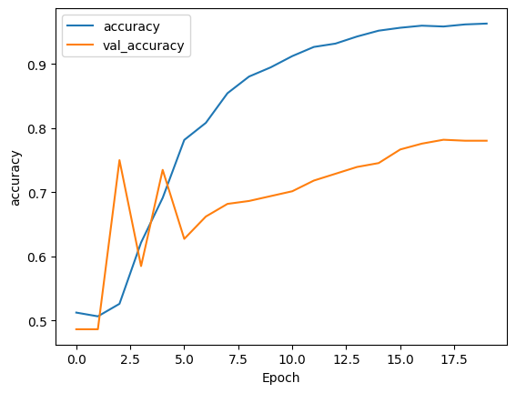

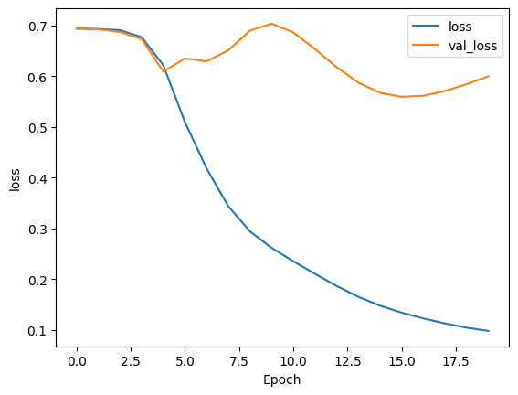

```python
# Resetting to padded length of 50

X_train, X_test, y_train, y_test, training_padded, training_label, test_padded, test_label = pad_split(50, False)

# Compiles and fits RNN model and provides model evaluation/summary measures on training and test data with predictions
def model_eval(model, train_pad=training_padded, train_labels=training_label, test_pad=test_padded, test_labels=test_label, X_tst=X_test, y_tst=y_test,
               loss='sparse_categorical_crossentropy', optimizer='adam', metrics=['accuracy'], batch_size=16, num_epochs=20, patience=10):
    validation_splitting = 0.3
    shfl = True
    vrbs = True
    test_index = np.random.randint(0, len(X_tst))

    model.compile(loss=loss, optimizer=optimizer, metrics=metrics)
    history = model.fit(train_pad, train_labels, batch_size=batch_size, epochs=num_epochs, validation_split=validation_splitting, shuffle=shfl,
                        callbacks=[EarlyStopping(patience=patience)], verbose=vrbs)
    print(model.summary())

    predictions_tr = model.predict(train_pad)
    predictions_te = model.predict(test_pad)

    print(f"\nText of review at index {test_index} to be predicted:\n{X_tst[test_index]}\n")
    print(f"Predicted: {'Negative' if predictions_te[test_index][0] >= 0.5 else 'Positive'} review\n")
    print(f"Actual: {'Negative' if y_tst[test_index] == 0 else 'Positive'} review\n")

    score_tr = model.evaluate(train_pad, train_labels, verbose=0)
    print(f"Training loss: {score_tr[0]} / Training accuracy: {score_tr[1]}")

    score_te = model.evaluate(test_pad, test_labels, verbose=0)
    print(f"Test loss: {score_te[0]} / Test accuracy: {score_te[1]}")

    predictions_te_converted = np.apply_along_axis(lambda x: 0 if x[0] >= 0.4999999 else 1, 1, predictions_te)
    cnfs_mtx = confusion_matrix(test_labels, predictions_te_converted)
    print(f"\nConfusion matrix on test data vs predictions:\n{cnfs_mtx}\n")

    plot_graphs(history, metrics[0])
    plot_graphs(history, "loss")
    return


model_softmax = model_creation(128, vocab_size, max_sequence_embedding, 'softmax')
model_eval(model_softmax)
```

Approximately the same, given the small random variations when the models are generated. The hidden Dense layer with 128 nodes uses the `relu` activation function to avoid the vanishing gradient problem and pass its output to the `sigmoid` activation in the final Dense layer of 2 nodes.

For the Embedding layer's input and output dimensions, let's first try a larger input dimension of 12000 (about 2.3 times as large as before):

```
97/97 ━━━━━━━━━━━━━━━━━━━━ 1s 3ms/step - accuracy: 0.5179 - loss: 0.6936 - val_accuracy: 0.4864 - val_loss: 0.6939
97/97 ━━━━━━━━━━━━━━━━━━━━ 0s 2ms/step - accuracy: 0.5150 - loss: 0.6926 - val_accuracy: 0.4864 - val_loss: 0.6930
97/97 ━━━━━━━━━━━━━━━━━━━━ 0s 2ms/step - accuracy: 0.5538 - loss: 0.6910 - val_accuracy: 0.4894 - val_loss: 0.6893
97/97 ━━━━━━━━━━━━━━━━━━━━ 0s 2ms/step - accuracy: 0.5762 - loss: 0.6831 - val_accuracy: 0.6576 - val_loss: 0.6758
97/97 ━━━━━━━━━━━━━━━━━━━━ 0s 2ms/step - accuracy: 0.6582 - loss: 0.6565 - val_accuracy: 0.7576 - val_loss: 0.6329
97/97 ━━━━━━━━━━━━━━━━━━━━ 0s 2ms/step - accuracy: 0.8233 - loss: 0.5717 - val_accuracy: 0.6318 - val_loss: 0.6132
97/97 ━━━━━━━━━━━━━━━━━━━━ 0s 2ms/step - accuracy: 0.7643 - loss: 0.4790 - val_accuracy: 0.6500 - val_loss: 0.6295
97/97 ━━━━━━━━━━━━━━━━━━━━ 0s 2ms/step - accuracy: 0.8116 - loss: 0.3975 - val_accuracy: 0.6742 - val_loss: 0.6449
97/97 ━━━━━━━━━━━━━━━━━━━━ 0s 2ms/step - accuracy: 0.8474 - loss: 0.3380 - val_accuracy: 0.6864 - val_loss: 0.6834
97/97 ━━━━━━━━━━━━━━━━━━━━ 0s 2ms/step - accuracy: 0.8720 - loss: 0.3008 - val_accuracy: 0.6894 - val_loss: 0.7075
97/97 ━━━━━━━━━━━━━━━━━━━━ 0s 2ms/step - accuracy: 0.8862 - loss: 0.2721 - val_accuracy: 0.7015 - val_loss: 0.6976
97/97 ━━━━━━━━━━━━━━━━━━━━ 0s 2ms/step - accuracy: 0.9076 - loss: 0.2428 - val_accuracy: 0.7227 - val_loss: 0.6634
97/97 ━━━━━━━━━━━━━━━━━━━━ 0s 2ms/step - accuracy: 0.9211 - loss: 0.2111 - val_accuracy: 0.7288 - val_loss: 0.6244
97/97 ━━━━━━━━━━━━━━━━━━━━ 0s 2ms/step - accuracy: 0.9331 - loss: 0.1799 - val_accuracy: 0.7364 - val_loss: 0.5912
97/97 ━━━━━━━━━━━━━━━━━━━━ 0s 2ms/step - accuracy: 0.9463 - loss: 0.1533 - val_accuracy: 0.7485 - val_loss: 0.5691
97/97 ━━━━━━━━━━━━━━━━━━━━ 0s 2ms/step - accuracy: 0.9630 - loss: 0.1330 - val_accuracy: 0.7682 - val_loss: 0.5596
97/97 ━━━━━━━━━━━━━━━━━━━━ 0s 2ms/step - accuracy: 0.9677 - loss: 0.1184 - val_accuracy: 0.7727 - val_loss: 0.5609
97/97 ━━━━━━━━━━━━━━━━━━━━ 0s 2ms/step - accuracy: 0.9643 - loss: 0.1076 - val_accuracy: 0.7773 - val_loss: 0.5697
97/97 ━━━━━━━━━━━━━━━━━━━━ 0s 2ms/step - accuracy: 0.9655 - loss: 0.0994 - val_accuracy: 0.7773 - val_loss: 0.5824
97/97 ━━━━━━━━━━━━━━━━━━━━ 0s 2ms/step - accuracy: 0.9652 - loss: 0.0931 - val_accuracy: 0.7788 - val_loss: 0.5969
```

```
Model: "sequential_90"
```

```
┏━━━━━━━━━━━━━━━━━━━━━━━━━━━━━━━━━━━━━━┳━━━━━━━━━━━━━━━━━━━━━━━━━━━━━┳━━━━━━━━━━━━━━━━━┓
┃ Layer (type)                         ┃ Output Shape                ┃         Param # ┃
┡━━━━━━━━━━━━━━━━━━━━━━━━━━━━━━━━━━━━━━╇━━━━━━━━━━━━━━━━━━━━━━━━━━━━━╇━━━━━━━━━━━━━━━━━┩
│ embedding_90 (Embedding)             │ (None, 50, 9)               │         108,000 │
├──────────────────────────────────────┼─────────────────────────────┼─────────────────┤
│ global_average_pooling1d_90          │ (None, 9)                   │               0 │
│ (GlobalAveragePooling1D)             │                             │                 │
├──────────────────────────────────────┼─────────────────────────────┼─────────────────┤
│ dense_187 (Dense)                    │ (None, 128)                 │           1,280 │
├──────────────────────────────────────┼─────────────────────────────┼─────────────────┤
│ dense_188 (Dense)                    │ (None, 2)                   │             258 │
└──────────────────────────────────────┴─────────────────────────────┴─────────────────┘
```

```
 Total params: 328,616 (1.25 MB)
```

```
 Trainable params: 109,538 (427.88 KB)
```

```
 Non-trainable params: 0 (0.00 B)
```

```
 Optimizer params: 219,078 (855.78 KB)
```

```
None
69/69 ━━━━━━━━━━━━━━━━━━━━ 0s 1ms/step
18/18 ━━━━━━━━━━━━━━━━━━━━ 0s 823us/step

Text of review at index 253 to be predicted:
update procedure difficult cumbersome

Predicted: Negative review

Actual: Negative review

Training loss: 0.24021479487419128 / Training accuracy: 0.913557767868042
Test loss: 0.5968762636184692 / Test accuracy: 0.7872727513313293

Confusion matrix on test data vs predictions:
[[233  40]
 [ 82 195]]
```

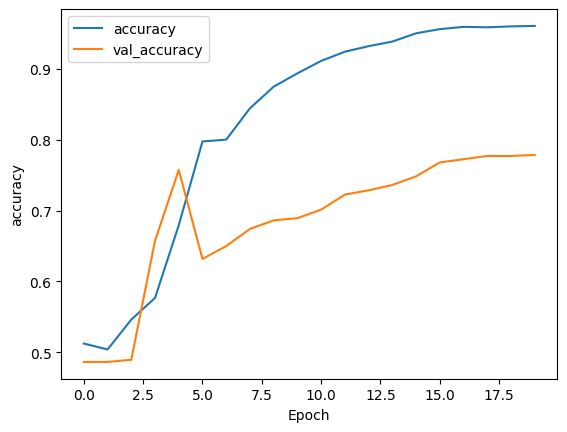

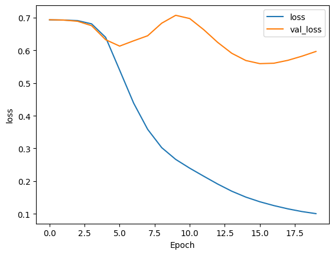

```python
model12000 = model_creation(nodes=128, vocabulary=12000, embedding_dim=max_sequence_embedding, activation='sigmoid')
model_eval(model12000)
```

It has no measurable impact, so it's maintained at the usual vocabulary size. Trying an embedding length more aligned with usual recommendations of 100-300 (Elleh, 2024 [1]):

```
97/97 ━━━━━━━━━━━━━━━━━━━━ 1s 7ms/step - accuracy: 0.4980 - loss: 0.6958 - val_accuracy: 0.4864 - val_loss: 0.6926
97/97 ━━━━━━━━━━━━━━━━━━━━ 1s 5ms/step - accuracy: 0.5252 - loss: 0.6925 - val_accuracy: 0.6045 - val_loss: 0.6896
97/97 ━━━━━━━━━━━━━━━━━━━━ 1s 5ms/step - accuracy: 0.5847 - loss: 0.6873 - val_accuracy: 0.5939 - val_loss: 0.6805
97/97 ━━━━━━━━━━━━━━━━━━━━ 1s 5ms/step - accuracy: 0.6452 - loss: 0.6609 - val_accuracy: 0.5500 - val_loss: 0.6712
97/97 ━━━━━━━━━━━━━━━━━━━━ 1s 5ms/step - accuracy: 0.6624 - loss: 0.5931 - val_accuracy: 0.6500 - val_loss: 0.6018
97/97 ━━━━━━━━━━━━━━━━━━━━ 1s 7ms/step - accuracy: 0.7911 - loss: 0.4327 - val_accuracy: 0.6530 - val_loss: 0.7094
97/97 ━━━━━━━━━━━━━━━━━━━━ 1s 5ms/step - accuracy: 0.8461 - loss: 0.3481 - val_accuracy: 0.7485 - val_loss: 0.4957
97/97 ━━━━━━━━━━━━━━━━━━━━ 1s 5ms/step - accuracy: 0.9144 - loss: 0.2378 - val_accuracy: 0.8000 - val_loss: 0.4756
97/97 ━━━━━━━━━━━━━━━━━━━━ 1s 5ms/step - accuracy: 0.9396 - loss: 0.1997 - val_accuracy: 0.7197 - val_loss: 0.5874
97/97 ━━━━━━━━━━━━━━━━━━━━ 1s 5ms/step - accuracy: 0.8605 - loss: 0.3108 - val_accuracy: 0.6697 - val_loss: 0.9460
97/97 ━━━━━━━━━━━━━━━━━━━━ 1s 5ms/step - accuracy: 0.9015 - loss: 0.2552 - val_accuracy: 0.6303 - val_loss: 1.1548
97/97 ━━━━━━━━━━━━━━━━━━━━ 1s 5ms/step - accuracy: 0.8914 - loss: 0.2560 - val_accuracy: 0.6258 - val_loss: 1.2647
97/97 ━━━━━━━━━━━━━━━━━━━━ 1s 5ms/step - accuracy: 0.8759 - loss: 0.2744 - val_accuracy: 0.6227 - val_loss: 1.3085
97/97 ━━━━━━━━━━━━━━━━━━━━ 1s 6ms/step - accuracy: 0.8521 - loss: 0.3487 - val_accuracy: 0.7061 - val_loss: 0.8188
97/97 ━━━━━━━━━━━━━━━━━━━━ 1s 6ms/step - accuracy: 0.8672 - loss: 0.2876 - val_accuracy: 0.7485 - val_loss: 0.5855
97/97 ━━━━━━━━━━━━━━━━━━━━ 1s 5ms/step - accuracy: 0.9473 - loss: 0.1433 - val_accuracy: 0.7424 - val_loss: 0.6511
97/97 ━━━━━━━━━━━━━━━━━━━━ 1s 5ms/step - accuracy: 0.9580 - loss: 0.1256 - val_accuracy: 0.7545 - val_loss: 0.6251
97/97 ━━━━━━━━━━━━━━━━━━━━ 1s 5ms/step - accuracy: 0.9625 - loss: 0.1070 - val_accuracy: 0.7682 - val_loss: 0.6082
```

```
Model: "sequential_92"
```

```
┏━━━━━━━━━━━━━━━━━━━━━━━━━━━━━━━━━━━━━━┳━━━━━━━━━━━━━━━━━━━━━━━━━━━━━┳━━━━━━━━━━━━━━━━━┓
┃ Layer (type)                         ┃ Output Shape                ┃         Param # ┃
┡━━━━━━━━━━━━━━━━━━━━━━━━━━━━━━━━━━━━━━╇━━━━━━━━━━━━━━━━━━━━━━━━━━━━━╇━━━━━━━━━━━━━━━━━┩
│ embedding_92 (Embedding)             │ (None, 50, 150)             │         790,800 │
├──────────────────────────────────────┼─────────────────────────────┼─────────────────┤
│ global_average_pooling1d_92          │ (None, 150)                 │               0 │
│ (GlobalAveragePooling1D)             │                             │                 │
├──────────────────────────────────────┼─────────────────────────────┼─────────────────┤
│ dense_191 (Dense)                    │ (None, 128)                 │          19,328 │
├──────────────────────────────────────┼─────────────────────────────┼─────────────────┤
│ dense_192 (Dense)                    │ (None, 2)                   │             258 │
└──────────────────────────────────────┴─────────────────────────────┴─────────────────┘
```

```
 Total params: 2,431,160 (9.27 MB)
```

```
 Trainable params: 810,386 (3.09 MB)
```

```
 Non-trainable params: 0 (0.00 B)
```

```
 Optimizer params: 1,620,774 (6.18 MB)
```

```
None
69/69 ━━━━━━━━━━━━━━━━━━━━ 0s 1ms/step
18/18 ━━━━━━━━━━━━━━━━━━━━ 0s 941us/step

Text of review at index 431 to be predicted:
downside service

Predicted: Negative review

Actual: Negative review

Training loss: 0.2471085488796234 / Training accuracy: 0.9080982804298401
Test loss: 0.6272655725479126 / Test accuracy: 0.7709090709686279

Confusion matrix on test data vs predictions:
[[236  37]
 [ 86 191]]
```

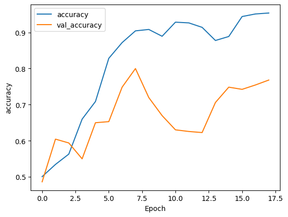

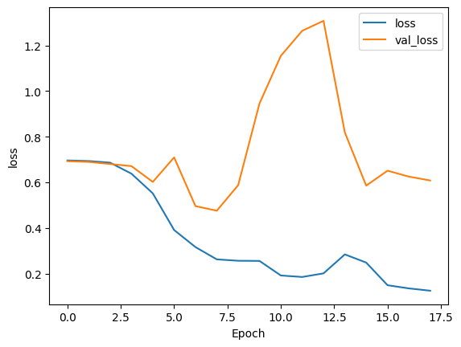

```python
model_embed = model_creation(nodes=128, vocabulary=vocab_size, embedding_dim=150, activation='sigmoid')
model_eval(model_embed)
```

The final Dense output layer must have 2 nodes to be compatible with the loss function `sparse_categorical_crossentropy`. The hidden Dense layer's node selection was tested to perform best at `nodes = 128`. Compare with `nodes = 64` below:

```
97/97 ━━━━━━━━━━━━━━━━━━━━ 1s 3ms/step - accuracy: 0.5169 - loss: 0.6934 - val_accuracy: 0.4864 - val_loss: 0.6941
97/97 ━━━━━━━━━━━━━━━━━━━━ 0s 2ms/step - accuracy: 0.5149 - loss: 0.6925 - val_accuracy: 0.4864 - val_loss: 0.6940
97/97 ━━━━━━━━━━━━━━━━━━━━ 0s 2ms/step - accuracy: 0.5181 - loss: 0.6912 - val_accuracy: 0.4864 - val_loss: 0.6920
97/97 ━━━━━━━━━━━━━━━━━━━━ 0s 2ms/step - accuracy: 0.5716 - loss: 0.6856 - val_accuracy: 0.5424 - val_loss: 0.6800
97/97 ━━━━━━━━━━━━━━━━━━━━ 0s 2ms/step - accuracy: 0.6249 - loss: 0.6685 - val_accuracy: 0.5091 - val_loss: 0.6665
97/97 ━━━━━━━━━━━━━━━━━━━━ 0s 2ms/step - accuracy: 0.7191 - loss: 0.6151 - val_accuracy: 0.7439 - val_loss: 0.5937
97/97 ━━━━━━━━━━━━━━━━━━━━ 0s 2ms/step - accuracy: 0.8225 - loss: 0.5152 - val_accuracy: 0.6545 - val_loss: 0.5962
97/97 ━━━━━━━━━━━━━━━━━━━━ 0s 2ms/step - accuracy: 0.8085 - loss: 0.4368 - val_accuracy: 0.6667 - val_loss: 0.6064
97/97 ━━━━━━━━━━━━━━━━━━━━ 0s 2ms/step - accuracy: 0.8444 - loss: 0.3694 - val_accuracy: 0.6864 - val_loss: 0.6143
97/97 ━━━━━━━━━━━━━━━━━━━━ 0s 1ms/step - accuracy: 0.8664 - loss: 0.3189 - val_accuracy: 0.6924 - val_loss: 0.6185
97/97 ━━━━━━━━━━━━━━━━━━━━ 0s 1ms/step - accuracy: 0.8993 - loss: 0.2797 - val_accuracy: 0.7106 - val_loss: 0.6151
97/97 ━━━━━━━━━━━━━━━━━━━━ 0s 2ms/step - accuracy: 0.9172 - loss: 0.2468 - val_accuracy: 0.7197 - val_loss: 0.6060
97/97 ━━━━━━━━━━━━━━━━━━━━ 0s 2ms/step - accuracy: 0.9238 - loss: 0.2181 - val_accuracy: 0.7258 - val_loss: 0.5944
97/97 ━━━━━━━━━━━━━━━━━━━━ 0s 1ms/step - accuracy: 0.9319 - loss: 0.1927 - val_accuracy: 0.7364 - val_loss: 0.5824
97/97 ━━━━━━━━━━━━━━━━━━━━ 0s 1ms/step - accuracy: 0.9416 - loss: 0.1706 - val_accuracy: 0.7379 - val_loss: 0.5721
97/97 ━━━━━━━━━━━━━━━━━━━━ 0s 2ms/step - accuracy: 0.9542 - loss: 0.1519 - val_accuracy: 0.7394 - val_loss: 0.5654
97/97 ━━━━━━━━━━━━━━━━━━━━ 0s 1ms/step - accuracy: 0.9632 - loss: 0.1365 - val_accuracy: 0.7455 - val_loss: 0.5633
97/97 ━━━━━━━━━━━━━━━━━━━━ 0s 1ms/step - accuracy: 0.9674 - loss: 0.1242 - val_accuracy: 0.7485 - val_loss: 0.5662
97/97 ━━━━━━━━━━━━━━━━━━━━ 0s 2ms/step - accuracy: 0.9678 - loss: 0.1144 - val_accuracy: 0.7576 - val_loss: 0.5729
97/97 ━━━━━━━━━━━━━━━━━━━━ 0s 1ms/step - accuracy: 0.9678 - loss: 0.1066 - val_accuracy: 0.7636 - val_loss: 0.5838
```

```
Model: "sequential_97"
```

```
┏━━━━━━━━━━━━━━━━━━━━━━━━━━━━━━━━━━━━━━┳━━━━━━━━━━━━━━━━━━━━━━━━━━━━━┳━━━━━━━━━━━━━━━━━┓
┃ Layer (type)                         ┃ Output Shape                ┃         Param # ┃
┡━━━━━━━━━━━━━━━━━━━━━━━━━━━━━━━━━━━━━━╇━━━━━━━━━━━━━━━━━━━━━━━━━━━━━╇━━━━━━━━━━━━━━━━━┩
│ embedding_97 (Embedding)             │ (None, 50, 9)               │          47,448 │
├──────────────────────────────────────┼─────────────────────────────┼─────────────────┤
│ global_average_pooling1d_97          │ (None, 9)                   │               0 │
│ (GlobalAveragePooling1D)             │                             │                 │
├──────────────────────────────────────┼─────────────────────────────┼─────────────────┤
│ dense_201 (Dense)                    │ (None, 64)                  │             640 │
├──────────────────────────────────────┼─────────────────────────────┼─────────────────┤
│ dense_202 (Dense)                    │ (None, 2)                   │             130 │
└──────────────────────────────────────┴─────────────────────────────┴─────────────────┘
```

```
 Total params: 144,656 (565.07 KB)
```

```
 Trainable params: 48,218 (188.35 KB)
```

```
 Non-trainable params: 0 (0.00 B)
```

```
 Optimizer params: 96,438 (376.71 KB)
```

```
None
69/69 ━━━━━━━━━━━━━━━━━━━━ 0s 1ms/step
18/18 ━━━━━━━━━━━━━━━━━━━━ 0s 763us/step

Text of review at index 519 to be predicted:
thing really worth watching wa scenery house beautiful

Predicted: Positive review

Actual: Positive review

Training loss: 0.2582451403141022 / Training accuracy: 0.8971792459487915
Test loss: 0.5989656448364258 / Test accuracy: 0.7636363506317139

Confusion matrix on test data vs predictions:
[[241  32]
 [ 97 180]]
```

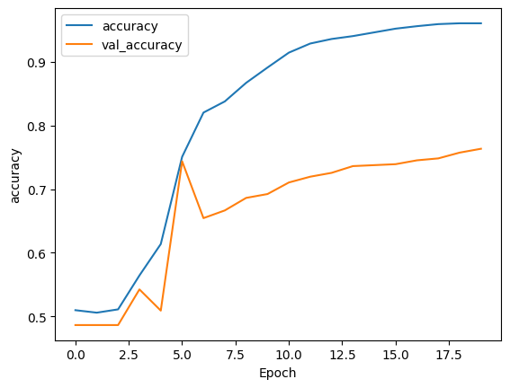

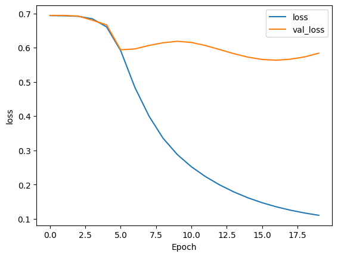

```python
model_64 = model_creation(nodes=64, vocabulary=vocab_size, embedding_dim=max_sequence_embedding, activation='sigmoid')
model_eval(model_64)
```

This model's accuracies are slightly worse compared to `nodes=128`.

Now trying `nodes = 256`:

```
97/97 ━━━━━━━━━━━━━━━━━━━━ 1s 3ms/step - accuracy: 0.5128 - loss: 0.6937 - val_accuracy: 0.4864 - val_loss: 0.6943
97/97 ━━━━━━━━━━━━━━━━━━━━ 0s 2ms/step - accuracy: 0.5141 - loss: 0.6927 - val_accuracy: 0.4864 - val_loss: 0.6932
97/97 ━━━━━━━━━━━━━━━━━━━━ 0s 1ms/step - accuracy: 0.5532 - loss: 0.6916 - val_accuracy: 0.4864 - val_loss: 0.6914
97/97 ━━━━━━━━━━━━━━━━━━━━ 0s 1ms/step - accuracy: 0.5338 - loss: 0.6843 - val_accuracy: 0.7530 - val_loss: 0.6759
97/97 ━━━━━━━━━━━━━━━━━━━━ 0s 2ms/step - accuracy: 0.6690 - loss: 0.6485 - val_accuracy: 0.6167 - val_loss: 0.6272
97/97 ━━━━━━━━━━━━━━━━━━━━ 0s 1ms/step - accuracy: 0.7300 - loss: 0.5463 - val_accuracy: 0.6379 - val_loss: 0.6319
97/97 ━━━━━━━━━━━━━━━━━━━━ 0s 2ms/step - accuracy: 0.7757 - loss: 0.4398 - val_accuracy: 0.6833 - val_loss: 0.6109
97/97 ━━━━━━━━━━━━━━━━━━━━ 0s 1ms/step - accuracy: 0.8340 - loss: 0.3517 - val_accuracy: 0.6879 - val_loss: 0.6569
97/97 ━━━━━━━━━━━━━━━━━━━━ 0s 1ms/step - accuracy: 0.8533 - loss: 0.3089 - val_accuracy: 0.6818 - val_loss: 0.7452
97/97 ━━━━━━━━━━━━━━━━━━━━ 0s 2ms/step - accuracy: 0.8645 - loss: 0.2935 - val_accuracy: 0.6727 - val_loss: 0.8128
97/97 ━━━━━━━━━━━━━━━━━━━━ 0s 2ms/step - accuracy: 0.8723 - loss: 0.2867 - val_accuracy: 0.6909 - val_loss: 0.7657
97/97 ━━━━━━━━━━━━━━━━━━━━ 0s 2ms/step - accuracy: 0.8890 - loss: 0.2600 - val_accuracy: 0.7227 - val_loss: 0.6596
97/97 ━━━━━━━━━━━━━━━━━━━━ 0s 1ms/step - accuracy: 0.9209 - loss: 0.2109 - val_accuracy: 0.7348 - val_loss: 0.6001
97/97 ━━━━━━━━━━━━━━━━━━━━ 0s 2ms/step - accuracy: 0.9366 - loss: 0.1705 - val_accuracy: 0.7485 - val_loss: 0.5753
97/97 ━━━━━━━━━━━━━━━━━━━━ 0s 1ms/step - accuracy: 0.9538 - loss: 0.1439 - val_accuracy: 0.7561 - val_loss: 0.5669
97/97 ━━━━━━━━━━━━━━━━━━━━ 0s 2ms/step - accuracy: 0.9637 - loss: 0.1258 - val_accuracy: 0.7652 - val_loss: 0.5674
97/97 ━━━━━━━━━━━━━━━━━━━━ 0s 1ms/step - accuracy: 0.9658 - loss: 0.1128 - val_accuracy: 0.7773 - val_loss: 0.5737
97/97 ━━━━━━━━━━━━━━━━━━━━ 0s 1ms/step - accuracy: 0.9649 - loss: 0.1029 - val_accuracy: 0.7788 - val_loss: 0.5846
97/97 ━━━━━━━━━━━━━━━━━━━━ 0s 1ms/step - accuracy: 0.9672 - loss: 0.0950 - val_accuracy: 0.7742 - val_loss: 0.5989
97/97 ━━━━━━━━━━━━━━━━━━━━ 0s 2ms/step - accuracy: 0.9681 - loss: 0.0886 - val_accuracy: 0.7773 - val_loss: 0.6157
```

```
Model: "sequential_98"
```

```
┏━━━━━━━━━━━━━━━━━━━━━━━━━━━━━━━━━━━━━━┳━━━━━━━━━━━━━━━━━━━━━━━━━━━━━┳━━━━━━━━━━━━━━━━━┓
┃ Layer (type)                         ┃ Output Shape                ┃         Param # ┃
┡━━━━━━━━━━━━━━━━━━━━━━━━━━━━━━━━━━━━━━╇━━━━━━━━━━━━━━━━━━━━━━━━━━━━━╇━━━━━━━━━━━━━━━━━┩
│ embedding_98 (Embedding)             │ (None, 50, 9)               │          47,448 │
├──────────────────────────────────────┼─────────────────────────────┼─────────────────┤
│ global_average_pooling1d_98          │ (None, 9)                   │               0 │
│ (GlobalAveragePooling1D)             │                             │                 │
├──────────────────────────────────────┼─────────────────────────────┼─────────────────┤
│ dense_203 (Dense)                    │ (None, 256)                 │           2,560 │
├──────────────────────────────────────┼─────────────────────────────┼─────────────────┤
│ dense_204 (Dense)                    │ (None, 2)                   │             514 │
└──────────────────────────────────────┴─────────────────────────────┴─────────────────┘
```

```
 Total params: 151,568 (592.07 KB)
```

```
 Trainable params: 50,522 (197.35 KB)
```

```
 Non-trainable params: 0 (0.00 B)
```

```
 Optimizer params: 101,046 (394.71 KB)
```

```
None
69/69 ━━━━━━━━━━━━━━━━━━━━ 0s 1ms/step
18/18 ━━━━━━━━━━━━━━━━━━━━ 0s 765us/step

Text of review at index 93 to be predicted:
new character memorable found forgetting wa

Predicted: Positive review

Actual: Negative review

Training loss: 0.24644707143306732 / Training accuracy: 0.9121928811073303
Test loss: 0.621461033821106 / Test accuracy: 0.778181791305542

Confusion matrix on test data vs predictions:
[[230  43]
 [ 78 199]]
```

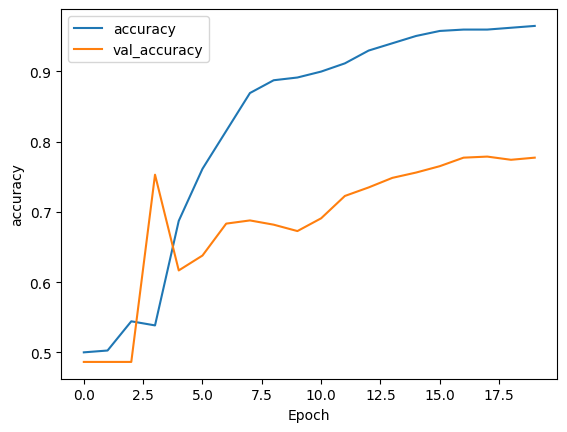

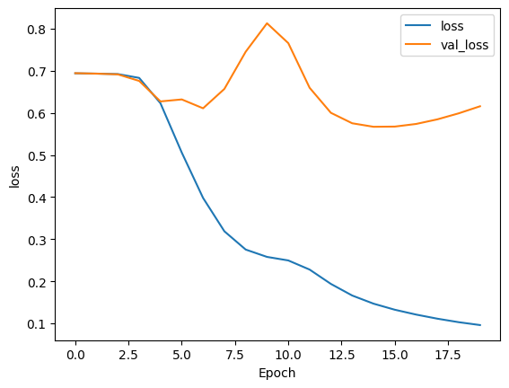

```python
model_256 = model_creation(nodes=256, vocabulary=vocab_size, embedding_dim=max_sequence_embedding, activation='sigmoid')
model_eval(model_256)
```

Approximately the same results as `nodes = 128`, so there's no reason to increase it.

Although binary crossentropy would be perfectly suited to this binary classification problem, sparse categorical crossentropy has the small advantage of future compatibility with data utilizing more than one class of sentiment. That would require refactoring the `sigmoid` activation function with `softmax`, which is a painless modification. Testing models with binary crossentropy (not depicted) had virtually identical computation time as with sparse categorical entropy, so with the potential generalization to multiple classes of sentiment in the future, sparse categorical entropy is the choice of loss function.

The optimization function `adam` is a widely used efficient optimizer that improves upon stochastic gradient descent with adaptability for handling noise and reducing overfitting (Elleh, 2024 [1]).

A more detailed discussion of stopping criteria will be presented in the following section. Ultimately, an early stopping monitor with a patience of 10 epochs monitoring the validation loss function was used. Attempts to monitor validation accuracy or adjust the thresholds or patience consistently underperformed. The oscillatory behavior of the validation loss function and the erratic swings of the validation accuracy in nearly all of the models tested would deceive the early stopping monitor into prematurely terminating and presenting suboptimal results compared to if it had run for all 20 epochs.

For this binary classification task, the natural evaluation metric to use is accuracy (the percentage of correct fitted labels to observed labels). This is assessed on the training, validation, and test data, with calculated values presented in the output for each model (see section C.1. for the final model's output). Additionally, the confusion matrix is recorded to assess any imbalance in the model's predictions of true positives vs true negatives and false positives vs false negatives (as the classes have very similar representation).

D.1. Stopping criteria

As mentioned in the previous section, the unusual behaviors of the loss functions made effective use of stopping criteria difficult and unreliable. The model trains through each epoch so quickly that the few seconds saved with early stopping is of marginal benefit while the model presented was either remarkably inferior (to all 20 epochs running) or slightly yet still within expected variations.

Normally, the neural network will run for all epochs as set in the `epochs` parameter. When stopping criteria are set within `EarlyStopping()`, the model monitors changes in a specified function (by default, this is the validation loss function but validation accuracy is another option) for a lack of improvement. If the value of this function hasn't improved from the best achieved value so far (with an improvement meeting the `min_delta` threshold) in a set number of epochs (set by the `patience` parameter), the model halts at its last completed epoch.

As mentioned in the previous section, the unusual behaviors of the loss functions made effective use of stopping criteria difficult and unreliable. The model trains through each epoch so quickly that the few seconds saved with early stopping is of marginal benefit while the model presented was either remarkably inferior (to all 20 epochs running) or slightly yet still within expected variations. If the model has an unusually good value in the monitored function in one epoch before returning to its normal behavior, a low value of `patience` will conclude the model can't be improved any further and will halth its construction. While this can be desirable in some cases to save processing time, in this project, when the monitored function has an outlier, the other three functions (of the four training loss, validation loss, training accuracy, and validation accuracy) still have improvements to be made, and the prematurely terminated model created is inferior to having run all 20 epochs.

To demonstrate some comparisons, when the stopping criteria monitor the validation accuracy for changes less than 0.005 over a patience of 5 epochs (with `restore_best_weights=True`):

```
97/97 ━━━━━━━━━━━━━━━━━━━━ 1s 3ms/step - accuracy: 0.5125 - loss: 0.6934 - val_accuracy: 0.4864 - val_loss: 0.6941
97/97 ━━━━━━━━━━━━━━━━━━━━ 0s 2ms/step - accuracy: 0.5160 - loss: 0.6926 - val_accuracy: 0.4864 - val_loss: 0.6937
97/97 ━━━━━━━━━━━━━━━━━━━━ 0s 2ms/step - accuracy: 0.5186 - loss: 0.6912 - val_accuracy: 0.4894 - val_loss: 0.6905
97/97 ━━━━━━━━━━━━━━━━━━━━ 0s 2ms/step - accuracy: 0.5695 - loss: 0.6860 - val_accuracy: 0.5561 - val_loss: 0.6810
97/97 ━━━━━━━━━━━━━━━━━━━━ 0s 2ms/step - accuracy: 0.6511 - loss: 0.6634 - val_accuracy: 0.7697 - val_loss: 0.6337
97/97 ━━━━━━━━━━━━━━━━━━━━ 0s 2ms/step - accuracy: 0.8115 - loss: 0.5737 - val_accuracy: 0.6076 - val_loss: 0.6394
97/97 ━━━━━━━━━━━━━━━━━━━━ 0s 2ms/step - accuracy: 0.7672 - loss: 0.4789 - val_accuracy: 0.6667 - val_loss: 0.6221
97/97 ━━━━━━━━━━━━━━━━━━━━ 0s 2ms/step - accuracy: 0.8228 - loss: 0.3829 - val_accuracy: 0.6848 - val_loss: 0.6394
97/97 ━━━━━━━━━━━━━━━━━━━━ 0s 2ms/step - accuracy: 0.8454 - loss: 0.3224 - val_accuracy: 0.6818 - val_loss: 0.7162
97/97 ━━━━━━━━━━━━━━━━━━━━ 0s 2ms/step - accuracy: 0.8591 - loss: 0.2967 - val_accuracy: 0.6742 - val_loss: 0.7866
```

```
Model: "sequential_107"
```

```
┏━━━━━━━━━━━━━━━━━━━━━━━━━━━━━━━━━━━━━━┳━━━━━━━━━━━━━━━━━━━━━━━━━━━━━┳━━━━━━━━━━━━━━━━━┓
┃ Layer (type)                         ┃ Output Shape                ┃         Param # ┃
┡━━━━━━━━━━━━━━━━━━━━━━━━━━━━━━━━━━━━━━╇━━━━━━━━━━━━━━━━━━━━━━━━━━━━━╇━━━━━━━━━━━━━━━━━┩
│ embedding_107 (Embedding)            │ (None, 50, 9)               │          47,448 │
├──────────────────────────────────────┼─────────────────────────────┼─────────────────┤
│ global_average_pooling1d_107         │ (None, 9)                   │               0 │
│ (GlobalAveragePooling1D)             │                             │                 │
├──────────────────────────────────────┼─────────────────────────────┼─────────────────┤
│ dense_222 (Dense)                    │ (None, 128)                 │           1,280 │
├──────────────────────────────────────┼─────────────────────────────┼─────────────────┤
│ dense_223 (Dense)                    │ (None, 2)                   │             258 │
└──────────────────────────────────────┴─────────────────────────────┴─────────────────┘
```

```
 Total params: 146,960 (574.07 KB)
```

```
 Trainable params: 48,986 (191.35 KB)
```

```
 Non-trainable params: 0 (0.00 B)
```

```
 Optimizer params: 97,974 (382.71 KB)
```

```
None
69/69 ━━━━━━━━━━━━━━━━━━━━ 0s 1ms/step
18/18 ━━━━━━━━━━━━━━━━━━━━ 0s 764us/step

Text of review at index 316 to be predicted:
worst hour half life oh gosh

Predicted: Negative review

Actual: Negative review

Training loss: 0.6007983088493347 / Training accuracy: 0.8730664253234863
Test loss: 0.6374942064285278 / Test accuracy: 0.7436363697052002

Confusion matrix on test data vs predictions:
[[227  46]
 [ 94 183]]
```

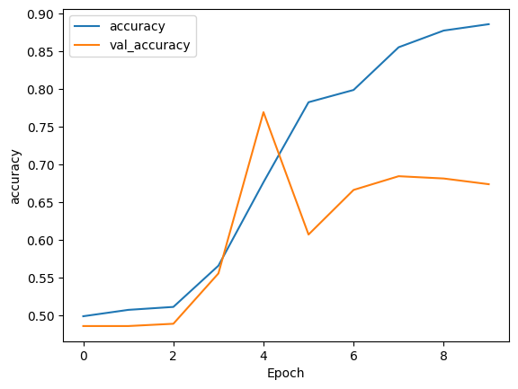

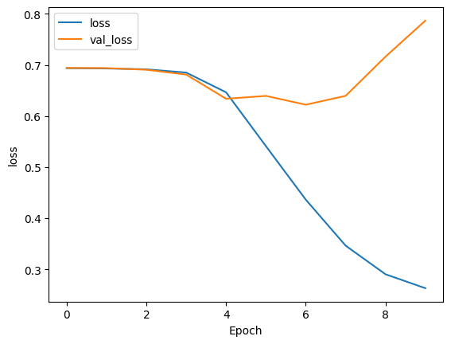

```python
# Compiles and fits RNN model and provides model evaluation/summary measures on training and test data with predictions
def model_eval(model, train_pad=training_padded, train_labels=training_label, test_pad=test_padded, test_labels=test_label, X_tst=X_test, y_tst=y_test,
               loss='sparse_categorical_crossentropy', optimizer='adam', metrics=['accuracy'], batch_size=16, num_epochs=20, patience=5):
    validation_splitting = 0.3
    shfl = True
    vrbs = True
    test_index = np.random.randint(0, len(X_tst))

    model.compile(loss=loss, optimizer=optimizer, metrics=metrics)
    history = model.fit(train_pad, train_labels, batch_size=batch_size, epochs=num_epochs, validation_split=validation_splitting, shuffle=shfl,
                        callbacks=[EarlyStopping(monitor='val_accuracy', min_delta=0.005, patience=patience, restore_best_weights=True)], verbose=vrbs)
    print(model.summary())

    predictions_tr = model.predict(train_pad)
    predictions_te = model.predict(test_pad)

    print(f"\nText of review at index {test_index} to be predicted:\n{X_tst[test_index]}\n")
    print(f"Predicted: {'Negative' if predictions_te[test_index][0] >= 0.5 else 'Positive'} review\n")
    print(f"Actual: {'Negative' if y_tst[test_index] == 0 else 'Positive'} review\n")

    score_tr = model.evaluate(train_pad, train_labels, verbose=0)
    print(f"Training loss: {score_tr[0]} / Training accuracy: {score_tr[1]}")

    score_te = model.evaluate(test_pad, test_labels, verbose=0)
    print(f"Test loss: {score_te[0]} / Test accuracy: {score_te[1]}")

    predictions_te_converted = np.apply_along_axis(lambda x: 0 if x[0] >= 0.4999999 else 1, 1, predictions_te)
    cnfs_mtx = confusion_matrix(test_labels, predictions_te_converted)
    print(f"\nConfusion matrix on test data vs predictions:\n{cnfs_mtx}\n")

    plot_graphs(history, metrics[0])
    plot_graphs(history, "loss")
    return


model_stop = model_creation()
model_eval(model_stop)
```

```
97/97 ━━━━━━━━━━━━━━━━━━━━ 1s 3ms/step - accuracy: 0.4985 - loss: 0.6937 - val_accuracy: 0.4864 - val_loss: 0.6937
97/97 ━━━━━━━━━━━━━━━━━━━━ 0s 1ms/step - accuracy: 0.5133 - loss: 0.6927 - val_accuracy: 0.4864 - val_loss: 0.6935
97/97 ━━━━━━━━━━━━━━━━━━━━ 0s 1ms/step - accuracy: 0.5253 - loss: 0.6916 - val_accuracy: 0.4864 - val_loss: 0.6904
97/97 ━━━━━━━━━━━━━━━━━━━━ 0s 1ms/step - accuracy: 0.5543 - loss: 0.6853 - val_accuracy: 0.5288 - val_loss: 0.6810
97/97 ━━━━━━━━━━━━━━━━━━━━ 0s 1ms/step - accuracy: 0.6110 - loss: 0.6659 - val_accuracy: 0.6273 - val_loss: 0.6483
97/97 ━━━━━━━━━━━━━━━━━━━━ 0s 1ms/step - accuracy: 0.8103 - loss: 0.5893 - val_accuracy: 0.6227 - val_loss: 0.6244
97/97 ━━━━━━━━━━━━━━━━━━━━ 0s 1ms/step - accuracy: 0.7519 - loss: 0.4987 - val_accuracy: 0.6470 - val_loss: 0.6344
97/97 ━━━━━━━━━━━━━━━━━━━━ 0s 1ms/step - accuracy: 0.8035 - loss: 0.4119 - val_accuracy: 0.6697 - val_loss: 0.6469
97/97 ━━━━━━━━━━━━━━━━━━━━ 0s 2ms/step - accuracy: 0.8431 - loss: 0.3490 - val_accuracy: 0.6788 - val_loss: 0.6861
97/97 ━━━━━━━━━━━━━━━━━━━━ 0s 2ms/step - accuracy: 0.8599 - loss: 0.3101 - val_accuracy: 0.6818 - val_loss: 0.7108
97/97 ━━━━━━━━━━━━━━━━━━━━ 0s 2ms/step - accuracy: 0.8806 - loss: 0.2804 - val_accuracy: 0.7000 - val_loss: 0.7000
97/97 ━━━━━━━━━━━━━━━━━━━━ 0s 2ms/step - accuracy: 0.9029 - loss: 0.2500 - val_accuracy: 0.7136 - val_loss: 0.6677
97/97 ━━━━━━━━━━━━━━━━━━━━ 0s 3ms/step - accuracy: 0.9172 - loss: 0.2177 - val_accuracy: 0.7273 - val_loss: 0.6301
```

```
Model: "sequential_104"
```

```
┏━━━━━━━━━━━━━━━━━━━━━━━━━━━━━━━━━━━━━━┳━━━━━━━━━━━━━━━━━━━━━━━━━━━━━┳━━━━━━━━━━━━━━━━━┓
┃ Layer (type)                         ┃ Output Shape                ┃         Param # ┃
┡━━━━━━━━━━━━━━━━━━━━━━━━━━━━━━━━━━━━━━╇━━━━━━━━━━━━━━━━━━━━━━━━━━━━━╇━━━━━━━━━━━━━━━━━┩
│ embedding_104 (Embedding)            │ (None, 50, 9)               │          47,448 │
├──────────────────────────────────────┼─────────────────────────────┼─────────────────┤
│ global_average_pooling1d_104         │ (None, 9)                   │               0 │
│ (GlobalAveragePooling1D)             │                             │                 │
├──────────────────────────────────────┼─────────────────────────────┼─────────────────┤
│ dense_216 (Dense)                    │ (None, 128)                 │           1,280 │
├──────────────────────────────────────┼─────────────────────────────┼─────────────────┤
│ dense_217 (Dense)                    │ (None, 2)                   │             258 │
└──────────────────────────────────────┴─────────────────────────────┴─────────────────┘
```

```
 Total params: 146,960 (574.07 KB)
```

```
 Trainable params: 48,986 (191.35 KB)
```

```
 Non-trainable params: 0 (0.00 B)
```

```
 Optimizer params: 97,974 (382.71 KB)
```

```
None
69/69 ━━━━━━━━━━━━━━━━━━━━ 0s 1ms/step
18/18 ━━━━━━━━━━━━━━━━━━━━ 0s 822us/step

Text of review at index 372 to be predicted:
story also funny poignant time

Predicted: Negative review

Actual: Positive review

Training loss: 0.5676518082618713 / Training accuracy: 0.6524112820625305
Test loss: 0.651840329170227 / Test accuracy: 0.5872727036476135

Confusion matrix on test data vs predictions:
[[270   3]
 [217  60]]
```

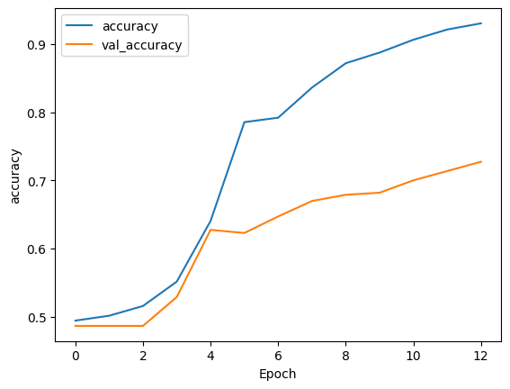

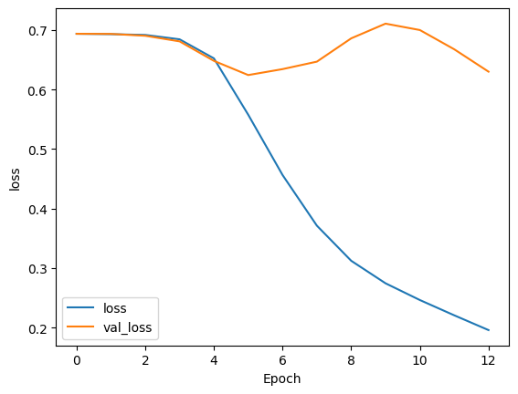

```python
# Compiles and fits RNN model and provides model evaluation/summary measures on training and test data with predictions
def model_eval(model, train_pad=training_padded, train_labels=training_label, test_pad=test_padded, test_labels=test_label, X_tst=X_test, y_tst=y_test,
               loss='sparse_categorical_crossentropy', optimizer='adam', metrics=['accuracy'], batch_size=16, num_epochs=20, patience=7):
    validation_splitting = 0.3
    shfl = True
    vrbs = True
    test_index = np.random.randint(0, len(X_tst))

    model.compile(loss=loss, optimizer=optimizer, metrics=metrics)
    history = model.fit(train_pad, train_labels, batch_size=batch_size, epochs=num_epochs, validation_split=validation_splitting, shuffle=shfl,
                        callbacks=[EarlyStopping(patience=patience, restore_best_weights=True)], verbose=vrbs)
    print(model.summary())

    predictions_tr = model.predict(train_pad)
    predictions_te = model.predict(test_pad)

    print(f"\nText of review at index {test_index} to be predicted:\n{X_tst[test_index]}\n")
    print(f"Predicted: {'Negative' if predictions_te[test_index][0] >= 0.5 else 'Positive'} review\n")
    print(f"Actual: {'Negative' if y_tst[test_index] == 0 else 'Positive'} review\n")

    score_tr = model.evaluate(train_pad, train_labels, verbose=0)
    print(f"Training loss: {score_tr[0]} / Training accuracy: {score_tr[1]}")

    score_te = model.evaluate(test_pad, test_labels, verbose=0)
    print(f"Test loss: {score_te[0]} / Test accuracy: {score_te[1]}")

    predictions_te_converted = np.apply_along_axis(lambda x: 0 if x[0] >= 0.4999999 else 1, 1, predictions_te)
    cnfs_mtx = confusion_matrix(test_labels, predictions_te_converted)
    print(f"\nConfusion matrix on test data vs predictions:\n{cnfs_mtx}\n")

    plot_graphs(history, metrics[0])
    plot_graphs(history, "loss")
    return


model_stop = model_creation()
model_eval(model_stop)
```

The model performs terribly. Moving on to a more standard patience of 3 epochs with nothing else changed relative to the final model:

```
97/97 ━━━━━━━━━━━━━━━━━━━━ 2s 3ms/step - accuracy: 0.5047 - loss: 0.6935 - val_accuracy: 0.4864 - val_loss: 0.6941
97/97 ━━━━━━━━━━━━━━━━━━━━ 0s 2ms/step - accuracy: 0.5149 - loss: 0.6926 - val_accuracy: 0.4864 - val_loss: 0.6934
97/97 ━━━━━━━━━━━━━━━━━━━━ 0s 2ms/step - accuracy: 0.5300 - loss: 0.6912 - val_accuracy: 0.4864 - val_loss: 0.6903
97/97 ━━━━━━━━━━━━━━━━━━━━ 0s 1ms/step - accuracy: 0.5374 - loss: 0.6832 - val_accuracy: 0.7485 - val_loss: 0.6735
97/97 ━━━━━━━━━━━━━━━━━━━━ 0s 2ms/step - accuracy: 0.6850 - loss: 0.6461 - val_accuracy: 0.6985 - val_loss: 0.6081
97/97 ━━━━━━━━━━━━━━━━━━━━ 0s 1ms/step - accuracy: 0.7611 - loss: 0.5423 - val_accuracy: 0.6273 - val_loss: 0.6347
97/97 ━━━━━━━━━━━━━━━━━━━━ 0s 1ms/step - accuracy: 0.7782 - loss: 0.4571 - val_accuracy: 0.6561 - val_loss: 0.6385
97/97 ━━━━━━━━━━━━━━━━━━━━ 0s 2ms/step - accuracy: 0.8210 - loss: 0.3842 - val_accuracy: 0.6652 - val_loss: 0.6627
```

```
Model: "sequential_106"
```

```
┏━━━━━━━━━━━━━━━━━━━━━━━━━━━━━━━━━━━━━━┳━━━━━━━━━━━━━━━━━━━━━━━━━━━━━┳━━━━━━━━━━━━━━━━━┓
┃ Layer (type)                         ┃ Output Shape                ┃         Param # ┃
┡━━━━━━━━━━━━━━━━━━━━━━━━━━━━━━━━━━━━━━╇━━━━━━━━━━━━━━━━━━━━━━━━━━━━━╇━━━━━━━━━━━━━━━━━┩
│ embedding_106 (Embedding)            │ (None, 50, 9)               │          47,448 │
├──────────────────────────────────────┼─────────────────────────────┼─────────────────┤
│ global_average_pooling1d_106         │ (None, 9)                   │               0 │
│ (GlobalAveragePooling1D)             │                             │                 │
├──────────────────────────────────────┼─────────────────────────────┼─────────────────┤
│ dense_220 (Dense)                    │ (None, 128)                 │           1,280 │
├──────────────────────────────────────┼─────────────────────────────┼─────────────────┤
│ dense_221 (Dense)                    │ (None, 2)                   │             258 │
└──────────────────────────────────────┴─────────────────────────────┴─────────────────┘
```

```
 Total params: 146,960 (574.07 KB)
```

```
 Trainable params: 48,986 (191.35 KB)
```

```
 Non-trainable params: 0 (0.00 B)
```

```
 Optimizer params: 97,974 (382.71 KB)
```

```
None
69/69 ━━━━━━━━━━━━━━━━━━━━ 0s 1ms/step
18/18 ━━━━━━━━━━━━━━━━━━━━ 0s 1ms/step

Text of review at index 486 to be predicted:
work fine

Predicted: Negative review

Actual: Positive review

Training loss: 0.5200371146202087 / Training accuracy: 0.718380331993103
Test loss: 0.7039220929145813 / Test accuracy: 0.6527272462844849

Confusion matrix on test data vs predictions:
[[270   3]
 [188  89]]
```

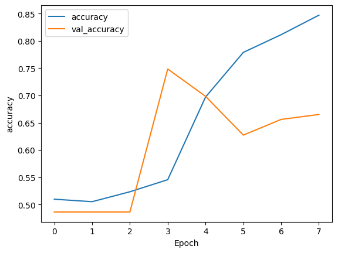

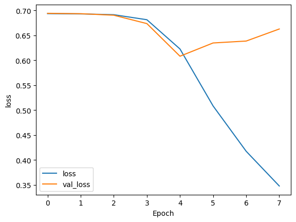

```python
# Compiles and fits RNN model and provides model evaluation/summary measures on training and test data with predictions
def model_eval(model, train_pad=training_padded, train_labels=training_label, test_pad=test_padded, test_labels=test_label, X_tst=X_test, y_tst=y_test,
               loss='sparse_categorical_crossentropy', optimizer='adam', metrics=['accuracy'], batch_size=16, num_epochs=20, patience=3):
    validation_splitting = 0.3
    shfl = True
    vrbs = True
    test_index = np.random.randint(0, len(X_tst))

    model.compile(loss=loss, optimizer=optimizer, metrics=metrics)
    history = model.fit(train_pad, train_labels, batch_size=batch_size, epochs=num_epochs, validation_split=validation_splitting, shuffle=shfl,
                        callbacks=[EarlyStopping(patience=patience)], verbose=vrbs)
    print(model.summary())

    predictions_tr = model.predict(train_pad)
    predictions_te = model.predict(test_pad)

    print(f"\nText of review at index {test_index} to be predicted:\n{X_tst[test_index]}\n")
    print(f"Predicted: {'Negative' if predictions_te[test_index][0] >= 0.5 else 'Positive'} review\n")
    print(f"Actual: {'Negative' if y_tst[test_index] == 0 else 'Positive'} review\n")

    score_tr = model.evaluate(train_pad, train_labels, verbose=0)
    print(f"Training loss: {score_tr[0]} / Training accuracy: {score_tr[1]}")

    score_te = model.evaluate(test_pad, test_labels, verbose=0)
    print(f"Test loss: {score_te[0]} / Test accuracy: {score_te[1]}")

    predictions_te_converted = np.apply_along_axis(lambda x: 0 if x[0] >= 0.4999999 else 1, 1, predictions_te)
    cnfs_mtx = confusion_matrix(test_labels, predictions_te_converted)
    print(f"\nConfusion matrix on test data vs predictions:\n{cnfs_mtx}\n")

    plot_graphs(history, metrics[0])
    plot_graphs(history, "loss")
    return


model_stop = model_creation()
model_eval(model_stop)
```

Again, the model cuts off prematurely at epoch 8 of 20 and performs poorly as a result. As described in section C.3., the validation loss and accuracy functions have unexpected, noisy patterns early on that deceive most combinations of parameters for an early stopping monitor. At the same time, the model performs fairly well when it's allowed to run to completion and has no observed benefit to go beyond 20 epochs. Under these circumstances, it's best to set high patience values or let the model run for all epochs unimpeded.

D.2. Fitness

The validation loss and test loss values were consistently quite high at ~0.6-0.7 while the final model's training loss was 0.24. This indicates the possibility of overfitting occuring, yet in contrast the validation accuracy (after some initial noise) tracks closely with the training accuracy. In addition, the model's predictions compared with the test data have an accuracy of 78.2% while the training accuracy is 91.3%. This 13.1% difference is a bit under the 15% threshold (Elleh, 2024 [3]) where overfitting is more evident, although it's close enough that it should be considered a strong possibility, especially given the undesirable behavior of the validation loss function and high test loss.

See below:

```
97/97 ━━━━━━━━━━━━━━━━━━━━ 1s 3ms/step - accuracy: 0.5057 - loss: 0.6936 - val_accuracy: 0.4864 - val_loss: 0.6943
97/97 ━━━━━━━━━━━━━━━━━━━━ 0s 2ms/step - accuracy: 0.5132 - loss: 0.6930 - val_accuracy: 0.4864 - val_loss: 0.6941
97/97 ━━━━━━━━━━━━━━━━━━━━ 0s 2ms/step - accuracy: 0.5140 - loss: 0.6927 - val_accuracy: 0.4864 - val_loss: 0.6935
97/97 ━━━━━━━━━━━━━━━━━━━━ 0s 2ms/step - accuracy: 0.5241 - loss: 0.6919 - val_accuracy: 0.4864 - val_loss: 0.6913
97/97 ━━━━━━━━━━━━━━━━━━━━ 0s 2ms/step - accuracy: 0.5503 - loss: 0.6878 - val_accuracy: 0.6212 - val_loss: 0.6828
97/97 ━━━━━━━━━━━━━━━━━━━━ 0s 2ms/step - accuracy: 0.6070 - loss: 0.6684 - val_accuracy: 0.5000 - val_loss: 0.6689
97/97 ━━━━━━━━━━━━━━━━━━━━ 0s 2ms/step - accuracy: 0.7206 - loss: 0.5810 - val_accuracy: 0.6879 - val_loss: 0.5741
97/97 ━━━━━━━━━━━━━━━━━━━━ 0s 2ms/step - accuracy: 0.8223 - loss: 0.4086 - val_accuracy: 0.7758 - val_loss: 0.4853
97/97 ━━━━━━━━━━━━━━━━━━━━ 0s 2ms/step - accuracy: 0.9134 - loss: 0.2680 - val_accuracy: 0.7530 - val_loss: 0.5043
97/97 ━━━━━━━━━━━━━━━━━━━━ 0s 2ms/step - accuracy: 0.8996 - loss: 0.2738 - val_accuracy: 0.6455 - val_loss: 0.8378
97/97 ━━━━━━━━━━━━━━━━━━━━ 0s 2ms/step - accuracy: 0.8554 - loss: 0.3307 - val_accuracy: 0.6970 - val_loss: 0.7868
97/97 ━━━━━━━━━━━━━━━━━━━━ 0s 2ms/step - accuracy: 0.9078 - loss: 0.2288 - val_accuracy: 0.6894 - val_loss: 0.9294
97/97 ━━━━━━━━━━━━━━━━━━━━ 0s 2ms/step - accuracy: 0.9127 - loss: 0.2293 - val_accuracy: 0.6985 - val_loss: 0.9046
97/97 ━━━━━━━━━━━━━━━━━━━━ 0s 2ms/step - accuracy: 0.8705 - loss: 0.3064 - val_accuracy: 0.7379 - val_loss: 0.6064
97/97 ━━━━━━━━━━━━━━━━━━━━ 0s 2ms/step - accuracy: 0.9173 - loss: 0.2091 - val_accuracy: 0.7909 - val_loss: 0.5367
97/97 ━━━━━━━━━━━━━━━━━━━━ 0s 1ms/step - accuracy: 0.9490 - loss: 0.1402 - val_accuracy: 0.7727 - val_loss: 0.5616
97/97 ━━━━━━━━━━━━━━━━━━━━ 0s 1ms/step - accuracy: 0.9541 - loss: 0.1346 - val_accuracy: 0.7773 - val_loss: 0.5846
97/97 ━━━━━━━━━━━━━━━━━━━━ 0s 2ms/step - accuracy: 0.9583 - loss: 0.1134 - val_accuracy: 0.7833 - val_loss: 0.5737
```

```
Model: "sequential_113"
```

```
┏━━━━━━━━━━━━━━━━━━━━━━━━━━━━━━━━━━━━━━┳━━━━━━━━━━━━━━━━━━━━━━━━━━━━━┳━━━━━━━━━━━━━━━━━┓
┃ Layer (type)                         ┃ Output Shape                ┃         Param # ┃
┡━━━━━━━━━━━━━━━━━━━━━━━━━━━━━━━━━━━━━━╇━━━━━━━━━━━━━━━━━━━━━━━━━━━━━╇━━━━━━━━━━━━━━━━━┩
│ embedding_113 (Embedding)            │ (None, 50, 9)               │          47,448 │
├──────────────────────────────────────┼─────────────────────────────┼─────────────────┤
│ global_average_pooling1d_113         │ (None, 9)                   │               0 │
│ (GlobalAveragePooling1D)             │                             │                 │
├──────────────────────────────────────┼─────────────────────────────┼─────────────────┤
│ dense_237 (Dense)                    │ (None, 128)                 │           1,280 │
├──────────────────────────────────────┼─────────────────────────────┼─────────────────┤
│ dropout_3 (Dropout)                  │ (None, 128)                 │               0 │
├──────────────────────────────────────┼─────────────────────────────┼─────────────────┤
│ dense_238 (Dense)                    │ (None, 64)                  │           8,256 │
├──────────────────────────────────────┼─────────────────────────────┼─────────────────┤
│ dense_239 (Dense)                    │ (None, 2)                   │             130 │
└──────────────────────────────────────┴─────────────────────────────┴─────────────────┘
```

```
 Total params: 171,344 (669.32 KB)
```

```
 Trainable params: 57,114 (223.10 KB)
```

```
 Non-trainable params: 0 (0.00 B)
```

```
 Optimizer params: 114,230 (446.21 KB)
```

```
None
69/69 ━━━━━━━━━━━━━━━━━━━━ 0s 1ms/step
18/18 ━━━━━━━━━━━━━━━━━━━━ 0s 823us/step

Text of review at index 254 to be predicted:
slow moving aimless movie distressed drifting young man

Predicted: Negative review

Actual: Negative review

Training loss: 0.2333119660615921 / Training accuracy: 0.9153776168823242
Test loss: 0.5897642374038696 / Test accuracy: 0.778181791305542

Confusion matrix on test data vs predictions:
[[224  49]
 [ 73 204]]
```

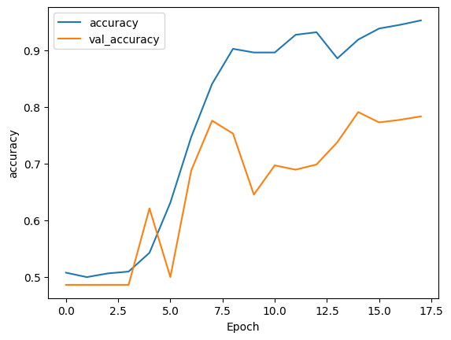

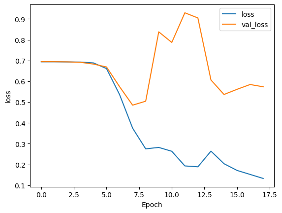

```python
def model_creation_3Dense(nodes=128, vocabulary=vocab_size, embedding_dim=max_sequence_embedding, activation='sigmoid'):
    model = Sequential([
        Embedding(input_dim=vocabulary, output_dim=embedding_dim),
        GlobalAveragePooling1D(),
        Dense(nodes, activation='relu'),
        Dropout(0.5),
        Dense(nodes//2, activation='relu'),
        Dense(2, activation=activation)
    ])
    return model


model_dropout = model_creation_3Dense()
model_eval(model_dropout)
```

The possibility of overfitting was further reduced by shuffling the data while the model was fitting and using a validation set to compare the model's performance with unknown data before being applied to the test data.

There are indications of some overfitting, but nothing extreme. Attempts to improve the behavior of the validation loss function were unsuccessful, consistently producing peculiar forms that found a minimum value at ~0.55-0.60. However, the validation accuracy increased at a similar (relative) rate as the training accuracy, indicating the model's reliable predictions with unseen data. Further, the final difference in accuracies of 0.913 for the training data and 0.782 for the test data show the overfitting is at most mild. Additional data could improve the model and reduce overfitting, as the validation and test splits on under 3000 reviews leaves relatively little for the model to be trained on.

D.3. Training process

```python
X_train, X_test, y_train, y_test, training_padded, training_label, test_padded, test_label = pad_split(50, False)
model0 = model_creation()
model_eval(model0)
```

```
Training size and testing size: (2198,), (550,)

97/97 ━━━━━━━━━━━━━━━━━━━━ 2s 4ms/step - accuracy: 0.5047 - loss: 0.6935 - val_accuracy: 0.4864 - val_loss: 0.6943
97/97 ━━━━━━━━━━━━━━━━━━━━ 0s 3ms/step - accuracy: 0.5174 - loss: 0.6927 - val_accuracy: 0.4864 - val_loss: 0.6935
97/97 ━━━━━━━━━━━━━━━━━━━━ 0s 3ms/step - accuracy: 0.5200 - loss: 0.6915 - val_accuracy: 0.4985 - val_loss: 0.6891
97/97 ━━━━━━━━━━━━━━━━━━━━ 0s 2ms/step - accuracy: 0.5788 - loss: 0.6831 - val_accuracy: 0.7652 - val_loss: 0.6738
97/97 ━━━━━━━━━━━━━━━━━━━━ 0s 2ms/step - accuracy: 0.6756 - loss: 0.6466 - val_accuracy: 0.7212 - val_loss: 0.6071
97/97 ━━━━━━━━━━━━━━━━━━━━ 0s 3ms/step - accuracy: 0.7658 - loss: 0.5421 - val_accuracy: 0.6273 - val_loss: 0.6349
97/97 ━━━━━━━━━━━━━━━━━━━━ 0s 2ms/step - accuracy: 0.7787 - loss: 0.4560 - val_accuracy: 0.6652 - val_loss: 0.6286
97/97 ━━━━━━━━━━━━━━━━━━━━ 0s 2ms/step - accuracy: 0.8306 - loss: 0.3750 - val_accuracy: 0.6833 - val_loss: 0.6521
97/97 ━━━━━━━━━━━━━━━━━━━━ 0s 3ms/step - accuracy: 0.8560 - loss: 0.3224 - val_accuracy: 0.6818 - val_loss: 0.6972
97/97 ━━━━━━━━━━━━━━━━━━━━ 0s 2ms/step - accuracy: 0.8759 - loss: 0.2902 - val_accuracy: 0.6833 - val_loss: 0.7180
97/97 ━━━━━━━━━━━━━━━━━━━━ 0s 2ms/step - accuracy: 0.8934 - loss: 0.2638 - val_accuracy: 0.7030 - val_loss: 0.7004
97/97 ━━━━━━━━━━━━━━━━━━━━ 0s 2ms/step - accuracy: 0.9152 - loss: 0.2357 - val_accuracy: 0.7182 - val_loss: 0.6588
97/97 ━━━━━━━━━━━━━━━━━━━━ 0s 3ms/step - accuracy: 0.9235 - loss: 0.2036 - val_accuracy: 0.7318 - val_loss: 0.6163
97/97 ━━━━━━━━━━━━━━━━━━━━ 0s 2ms/step - accuracy: 0.9343 - loss: 0.1726 - val_accuracy: 0.7364 - val_loss: 0.5818
97/97 ━━━━━━━━━━━━━━━━━━━━ 0s 2ms/step - accuracy: 0.9532 - loss: 0.1472 - val_accuracy: 0.7485 - val_loss: 0.5602
97/97 ━━━━━━━━━━━━━━━━━━━━ 0s 2ms/step - accuracy: 0.9633 - loss: 0.1283 - val_accuracy: 0.7667 - val_loss: 0.5525
97/97 ━━━━━━━━━━━━━━━━━━━━ 0s 2ms/step - accuracy: 0.9660 - loss: 0.1148 - val_accuracy: 0.7712 - val_loss: 0.5561
97/97 ━━━━━━━━━━━━━━━━━━━━ 0s 2ms/step - accuracy: 0.9660 - loss: 0.1049 - val_accuracy: 0.7727 - val_loss: 0.5664
97/97 ━━━━━━━━━━━━━━━━━━━━ 0s 2ms/step - accuracy: 0.9674 - loss: 0.0971 - val_accuracy: 0.7742 - val_loss: 0.5803
97/97 ━━━━━━━━━━━━━━━━━━━━ 0s 2ms/step - accuracy: 0.9670 - loss: 0.0911 - val_accuracy: 0.7758 - val_loss: 0.5965
```

```
Model: "sequential_77"
```

```
┏━━━━━━━━━━━━━━━━━━━━━━━━━━━━━━━━━━━━━━┳━━━━━━━━━━━━━━━━━━━━━━━━━━━━━┳━━━━━━━━━━━━━━━━━┓
┃ Layer (type)                         ┃ Output Shape                ┃         Param # ┃
┡━━━━━━━━━━━━━━━━━━━━━━━━━━━━━━━━━━━━━━╇━━━━━━━━━━━━━━━━━━━━━━━━━━━━━╇━━━━━━━━━━━━━━━━━┩
│ embedding_77 (Embedding)             │ (None, 50, 9)               │          47,448 │
├──────────────────────────────────────┼─────────────────────────────┼─────────────────┤
│ global_average_pooling1d_77          │ (None, 9)                   │               0 │
│ (GlobalAveragePooling1D)             │                             │                 │
├──────────────────────────────────────┼─────────────────────────────┼─────────────────┤
│ dense_160 (Dense)                    │ (None, 128)                 │           1,280 │
├──────────────────────────────────────┼─────────────────────────────┼─────────────────┤
│ dense_161 (Dense)                    │ (None, 2)                   │             258 │
└──────────────────────────────────────┴─────────────────────────────┴─────────────────┘
```

```
 Total params: 146,960 (574.07 KB)
```

```
 Trainable params: 48,986 (191.35 KB)
```

```
 Non-trainable params: 0 (0.00 B)
```

```
 Optimizer params: 97,974 (382.71 KB)
```

```
None
69/69 ━━━━━━━━━━━━━━━━━━━━ 0s 1ms/step
18/18 ━━━━━━━━━━━━━━━━━━━━ 0s 823us/step

Text of review at index 82 to be predicted:
take business dinner dollar elsewhere

Predicted: Negative review

Actual: Negative review

Training loss: 0.23992300033569336 / Training accuracy: 0.9126478433609009
Test loss: 0.6005603671073914 / Test accuracy: 0.7818182110786438

Confusion matrix on test data vs predictions:
[[225  48]
 [ 66 211]]
```

D.4. Predictive accuracy

The model's summary and evaluation output, including its accuracy with predictions vs observed data, are reprinted below:

```python
X_train, X_test, y_train, y_test, training_padded, training_label, test_padded, test_label = pad_split(50, False)
model0 = model_creation()
model_eval(model0)
```

```
Training size and testing size: (2198,), (550,)

97/97 ━━━━━━━━━━━━━━━━━━━━ 2s 4ms/step - accuracy: 0.5047 - loss: 0.6935 - val_accuracy: 0.4864 - val_loss: 0.6943
97/97 ━━━━━━━━━━━━━━━━━━━━ 0s 3ms/step - accuracy: 0.5174 - loss: 0.6927 - val_accuracy: 0.4864 - val_loss: 0.6935
97/97 ━━━━━━━━━━━━━━━━━━━━ 0s 3ms/step - accuracy: 0.5200 - loss: 0.6915 - val_accuracy: 0.4985 - val_loss: 0.6891
97/97 ━━━━━━━━━━━━━━━━━━━━ 0s 2ms/step - accuracy: 0.5788 - loss: 0.6831 - val_accuracy: 0.7652 - val_loss: 0.6738
97/97 ━━━━━━━━━━━━━━━━━━━━ 0s 2ms/step - accuracy: 0.6756 - loss: 0.6466 - val_accuracy: 0.7212 - val_loss: 0.6071
97/97 ━━━━━━━━━━━━━━━━━━━━ 0s 3ms/step - accuracy: 0.7658 - loss: 0.5421 - val_accuracy: 0.6273 - val_loss: 0.6349
97/97 ━━━━━━━━━━━━━━━━━━━━ 0s 2ms/step - accuracy: 0.7787 - loss: 0.4560 - val_accuracy: 0.6652 - val_loss: 0.6286
97/97 ━━━━━━━━━━━━━━━━━━━━ 0s 2ms/step - accuracy: 0.8306 - loss: 0.3750 - val_accuracy: 0.6833 - val_loss: 0.6521
97/97 ━━━━━━━━━━━━━━━━━━━━ 0s 3ms/step - accuracy: 0.8560 - loss: 0.3224 - val_accuracy: 0.6818 - val_loss: 0.6972
97/97 ━━━━━━━━━━━━━━━━━━━━ 0s 2ms/step - accuracy: 0.8759 - loss: 0.2902 - val_accuracy: 0.6833 - val_loss: 0.7180
97/97 ━━━━━━━━━━━━━━━━━━━━ 0s 2ms/step - accuracy: 0.8934 - loss: 0.2638 - val_accuracy: 0.7030 - val_loss: 0.7004
97/97 ━━━━━━━━━━━━━━━━━━━━ 0s 2ms/step - accuracy: 0.9152 - loss: 0.2357 - val_accuracy: 0.7182 - val_loss: 0.6588
97/97 ━━━━━━━━━━━━━━━━━━━━ 0s 3ms/step - accuracy: 0.9235 - loss: 0.2036 - val_accuracy: 0.7318 - val_loss: 0.6163
97/97 ━━━━━━━━━━━━━━━━━━━━ 0s 2ms/step - accuracy: 0.9343 - loss: 0.1726 - val_accuracy: 0.7364 - val_loss: 0.5818
97/97 ━━━━━━━━━━━━━━━━━━━━ 0s 2ms/step - accuracy: 0.9532 - loss: 0.1472 - val_accuracy: 0.7485 - val_loss: 0.5602
97/97 ━━━━━━━━━━━━━━━━━━━━ 0s 2ms/step - accuracy: 0.9633 - loss: 0.1283 - val_accuracy: 0.7667 - val_loss: 0.5525
97/97 ━━━━━━━━━━━━━━━━━━━━ 0s 2ms/step - accuracy: 0.9660 - loss: 0.1148 - val_accuracy: 0.7712 - val_loss: 0.5561
97/97 ━━━━━━━━━━━━━━━━━━━━ 0s 2ms/step - accuracy: 0.9660 - loss: 0.1049 - val_accuracy: 0.7727 - val_loss: 0.5664
97/97 ━━━━━━━━━━━━━━━━━━━━ 0s 2ms/step - accuracy: 0.9674 - loss: 0.0971 - val_accuracy: 0.7742 - val_loss: 0.5803
97/97 ━━━━━━━━━━━━━━━━━━━━ 0s 2ms/step - accuracy: 0.9670 - loss: 0.0911 - val_accuracy: 0.7758 - val_loss: 0.5965
```

```
Model: "sequential_77"
```

```
┏━━━━━━━━━━━━━━━━━━━━━━━━━━━━━━━━━━━━━━┳━━━━━━━━━━━━━━━━━━━━━━━━━━━━━┳━━━━━━━━━━━━━━━━━┓
┃ Layer (type)                         ┃ Output Shape                ┃         Param # ┃
┡━━━━━━━━━━━━━━━━━━━━━━━━━━━━━━━━━━━━━━╇━━━━━━━━━━━━━━━━━━━━━━━━━━━━━╇━━━━━━━━━━━━━━━━━┩
│ embedding_77 (Embedding)             │ (None, 50, 9)               │          47,448 │
├──────────────────────────────────────┼─────────────────────────────┼─────────────────┤
│ global_average_pooling1d_77          │ (None, 9)                   │               0 │
│ (GlobalAveragePooling1D)             │                             │                 │
├──────────────────────────────────────┼─────────────────────────────┼─────────────────┤
│ dense_160 (Dense)                    │ (None, 128)                 │           1,280 │
├──────────────────────────────────────┼─────────────────────────────┼─────────────────┤
│ dense_161 (Dense)                    │ (None, 2)                   │             258 │
└──────────────────────────────────────┴─────────────────────────────┴─────────────────┘
```

```
 Total params: 146,960 (574.07 KB)
```

```
 Trainable params: 48,986 (191.35 KB)
```

```
 Non-trainable params: 0 (0.00 B)
```

```
 Optimizer params: 97,974 (382.71 KB)
```

```
None
69/69 ━━━━━━━━━━━━━━━━━━━━ 0s 1ms/step
18/18 ━━━━━━━━━━━━━━━━━━━━ 0s 823us/step

Text of review at index 82 to be predicted:
take business dinner dollar elsewhere

Predicted: Negative review

Actual: Negative review

Training loss: 0.23992300033569336 / Training accuracy: 0.9126478433609009
Test loss: 0.6005603671073914 / Test accuracy: 0.7818182110786438

Confusion matrix on test data vs predictions:
[[225  48]
 [ 66 211]]
```

The dataset has 1386 reviews with positive sentiment and 1362 with negative sentiment, so the ideal confusion matrix would have 277 true positives and 273 true negatives. Comparably, there is a slight bias for false negatives compared to false positives, but overall the distribution within the confusion matrix is fairly balanced.

Unfortunately, the model had a relatively high value on the validation loss, never going below 0.55, and the loss on the test data was 0.60, compared to the loss on the training data being 0.24. Nonetheless, the model's validation accuracy follows a similar pattern to the training accuracy after an initial chaotic phase, so along with the 78.2% accuracy on the test data, the model is a reliable predictor of positive and negative sentiments from user reviews. The difference between training and test data accuracies of ~0.13 is below the 0.15 threshold where overfitting is of greater concern (Elleh, 2024 [3]). It does still display signs of some overfitting yet can predict binary sentiment values with reasonable accuracy.

E. Code

The model is saved using the following:

```python
# Saving model
model0.save('RNN_review_sentiment.keras')
```

The code for this project in its entirey is reprinted below:

```python
import pandas as pd
import numpy as np
import matplotlib.pyplot as plt
import re
from sklearn.model_selection import train_test_split
from sklearn.metrics import confusion_matrix
from tensorflow import random as tf_random
from tensorflow.keras.models import load_model
from tensorflow.keras.preprocessing.text import Tokenizer
from tensorflow.keras.callbacks import EarlyStopping
from tensorflow.keras.layers import Dense, Embedding, GlobalAveragePooling1D
from tensorflow.keras.models import Sequential
from tensorflow.keras.preprocessing.sequence import pad_sequences
from nltk import word_tokenize, WordNetLemmatizer
from nltk.corpus import stopwords


# Adapted from Dr. Festus Elleh's “D213 Task 2 Data Preprocessing in Python” and “D213 Task 2 Building NN Model in Python” lecture videos, accessed 2024.
# https://wgu.hosted.panopto.com/Panopto/Pages/Viewer.aspx?id=8639374a-964b-4ae9-b33b-b1210052c07d
# https://wgu.hosted.panopto.com/Panopto/Pages/Viewer.aspx?id=1b9aff54-735f-456a-a6b4-b11b00eb8d2f

# Set to true for greater output (takes longer to run)
verbose = False


df_amz = pd.read_csv('data/D213-sentiment_labelled_sentences-files/sentiment labelled sentences/amazon_cells_labelled.txt',
                     delimiter='\t', header=None, names=['review', 'sentiment'])
df_amz['source'] = 'Amazon'
df_imdb = pd.read_csv('data/D213-sentiment_labelled_sentences-files/sentiment labelled sentences/imdb_labelled.txt',
                      delimiter='\t', header=None, names=['review', 'sentiment'])
df_imdb['source'] = 'IMDB'
df_yelp = pd.read_csv('data/D213-sentiment_labelled_sentences-files/sentiment labelled sentences/yelp_labelled.txt',
                      delimiter='\t', header=None, names=['review', 'sentiment'])
df_yelp['source'] = 'Yelp'

df = pd.concat([df_amz, df_imdb, df_yelp], ignore_index=True)
print(df)

# Verifying dataframe has no null values
df.isnull().sum()

if verbose:
    plt.hist(df['sentiment'])
    plt.show()



# Creates a list of unique characters 'list_of_chars' and list of unique words 'word_bag' from input 'reviews'
def char_word_bags(reviews=df['review'], display=False):
    list_of_chars = []
    word_bag = []
    for comment in reviews:
        for character in comment:
            if character not in list_of_chars:
                list_of_chars.append(character)
    if display:
        print(list_of_chars)

    for revw in reviews:
        for word in revw.split(" "):
            if word not in word_bag:
                word_bag.append(word)
    if display:
        print(word_bag)

    return list_of_chars, word_bag


if verbose:
    raw_char_list, raw_word_bag = char_word_bags(df['review'], False)
    print(f"\nList of unique characters (before processing):\n{raw_char_list}\n")
    print(f"\nList of unique words (before processing):\n{raw_word_bag}\n")



stop_words = stopwords.words('english')
description_list = []
raw_reviews = []
for description in df['review']:
    raw_reviews.append(description)
    #remove punctuation, special characters, single characters, and multiple spaces
    description = re.sub("[^a-zA-Z]", " ", description)
    description = re.sub("\s+[a-zA-Z]\s+", " ", description)
    description = re.sub("\s+", " ", description)

    #convert to lower case
    description = description.lower()

    # tokenization
    description = word_tokenize(description)

    # lemmatization
    lemma = WordNetLemmatizer()
    description = [lemma.lemmatize(word) for word in description]

    # removing stop words
    description = [word for word in description if not word in stop_words]
    description = " ".join(description)
    description_list.append(description)


if verbose:
    print(f"\nStop words:\n{stop_words}\n")
    print(f"\nOriginal reviews:\n{raw_reviews}\n")
    print(f"\nCleaned reviews:\n{description_list}\n")
    clean_char_list, clean_word_bag = char_word_bags(description_list, False)
    print(f"List of unique characters (after processing):\n{clean_char_list}\n")
    print(f"Length of above list (expecting 26 letters and 1 space): {len(clean_char_list)}\n")
    print(f"List of unique words (after processing):\n{clean_word_bag}\n")



# Tokenizing
tokens = Tokenizer()
tokens.fit_on_texts(df['review'])
vocab_size = len(tokens.word_index) + 1
max_sequence_embedding = int(np.sqrt(np.sqrt(vocab_size)) // 1 + 1)

print(f"Vocabulary size: {vocab_size}\n")
print(f"Embedding length (vocab_size^(1/4) (rounded up to nearest integer)): {max_sequence_embedding}\n")
if verbose:
    print(f"Word index:\n{tokens.word_index}\n")



# Finding min, median, mean, and max lengths of reviews. Also creating arrays for reviews of length over long_rev_thresh.
long_rev_thresh = 50
long_rev_text = []
review_length = []
for rev in df['review']:
    rev_length = len(rev.split(" "))
    review_length.append(rev_length)
    if rev_length > long_rev_thresh:
        long_rev_text.append(rev)

review_max = np.max(review_length)
review_mean = np.mean(review_length)
review_median = np.median(review_length)
review_min = np.min(review_length)
print(f"Maximum review length (words): {review_max}\n")
print(f"Mean review length (words): {round(review_mean, 2)}\n")
print(f"Median review length (words): {review_median}\n")
print(f"Minimum review length (words): {review_min}\n")

if verbose:
    hist_review_lengths = np.array(review_length)
    print(f"There are {len(long_rev_text)} reviews above {long_rev_thresh} characters:\n{long_rev_text}\n")
    plt.hist(hist_review_lengths[hist_review_lengths >= long_rev_thresh])
    plt.xlim(long_rev_thresh, review_max + 1)
    plt.xlabel('Review length (words)')
    plt.title(f'Distribution of reviews with length over {long_rev_thresh}')
    plt.show()
    plt.hist(hist_review_lengths[hist_review_lengths < long_rev_thresh], bins=long_rev_thresh)
    plt.xlim(0, long_rev_thresh + 1)
    plt.xlabel('Review length (words)')
    plt.title(f'Distribution of reviews with length below {long_rev_thresh}')
    plt.show()



# Splits data into training and test sets then pads according to 'max_padding_length', with padding and truncating both occuring 'post'.
def pad_split(max_padding_length, save=False):
    X = np.array(description_list)
    y = df['sentiment'].values

    # Setting random seeds
    rd = 40
    tf_random.set_seed(16)

    X_train, X_test, y_train, y_test = train_test_split(X, y, test_size=0.20, random_state=rd, stratify=y)

    y_train = pd.Series(y_train)
    y_test = pd.Series(y_test)

    print(f"Training size and testing size: {X_train.shape}, {X_test.shape}\n")

    max_length_pad = max_padding_length
    padding_type = 'post'
    trunc_type = 'post'

    sequences_train = tokens.texts_to_sequences(X_train)
    padded_train = pad_sequences(sequences_train, maxlen=max_length_pad, padding=padding_type, truncating=trunc_type)

    sequences_test = tokens.texts_to_sequences(X_test)
    padded_test = pad_sequences(sequences_test, maxlen=max_length_pad, padding=padding_type, truncating=trunc_type)

    training_padded = np.array(padded_train)
    training_label = np.array(y_train)
    test_padded = np.array(padded_test)
    test_label = np.array(y_test)

    if save:
        pd.DataFrame(training_padded).to_csv("training_padded.csv")
        pd.DataFrame(training_label).to_csv("training_label.csv")
        pd.DataFrame(test_padded).to_csv("test_padded.csv")
        pd.DataFrame(test_label).to_csv("test_label.csv")

    return X_train, X_test, y_train, y_test, training_padded, training_label, test_padded, test_label


X_train, X_test, y_train, y_test, training_padded, training_label, test_padded, test_label = pad_split(50, False)

if verbose:
    print(training_padded[15])




# Creates RNN with an embedding layer determined by 'vocabulary' and 'embedding_dim', then uses a GlobalAveragePooling1D layer, and two dense layers.
# The first dense layer has nodes 'nodes' (using 'relu') and the second uses the activation function 'activation'.
def model_creation(nodes=128, vocabulary=vocab_size, embedding_dim=max_sequence_embedding, activation='sigmoid'):
    model = Sequential([
        Embedding(input_dim=vocabulary, output_dim=embedding_dim),
        GlobalAveragePooling1D(),
        Dense(nodes, activation='relu'),
        Dense(2, activation=activation)
    ])
    return model


# Creates RNN with an embedding layer determined by 'vocabulary' and 'embedding_dim', then uses a GlobalAveragePooling1D layer, and three dense layers.
# The first dense layer has nodes 'nodes', the second has nodes 'nodes//2' (both use 'relu'), and the third uses the activation function 'activation'.
def model_creation_3Dense(nodes=128, vocabulary=vocab_size, embedding_dim=max_sequence_embedding, activation='sigmoid'):
    model = Sequential([
        Embedding(input_dim=vocabulary, output_dim=embedding_dim),
        GlobalAveragePooling1D(),
        Dense(nodes, activation='relu'),
        Dense(nodes//2, activation='relu'),
        Dense(2, activation=activation)
    ])
    return model


# Plot the metric (such as accuracy or loss) and its validation score vs epoch
def plot_graphs(history, metric):
    plt.plot(history.history[metric])
    plt.plot(history.history['val_'+metric])
    plt.xlabel("Epoch")
    plt.ylabel(metric)
    plt.legend([metric, 'val_'+metric])
    plt.show()
    return


# Compiles and fits RNN model and provides model evaluation/summary measures on training and test data with predictions
def model_eval(model, train_pad=training_padded, train_labels=training_label, test_pad=test_padded, test_labels=test_label, X_tst=X_test, y_tst=y_test,
               loss='sparse_categorical_crossentropy', optimizer='adam', metrics=['accuracy'], batch_size=16, num_epochs=20, patience=10):
    validation_splitting = 0.3
    shfl = True
    vrbs = True
    test_index = np.random.randint(0, len(X_tst))

    model.compile(loss=loss, optimizer=optimizer, metrics=metrics)
    history = model.fit(train_pad, train_labels, batch_size=batch_size, epochs=num_epochs, validation_split=validation_splitting, shuffle=shfl,
                        callbacks=[EarlyStopping(patience=patience)], verbose=vrbs)
    print(model.summary())

    predictions_tr = model.predict(train_pad)
    predictions_te = model.predict(test_pad)

    print(f"\nText of review at index {test_index} to be predicted:\n{X_tst[test_index]}\n")
    print(f"Predicted: {'Negative' if predictions_te[test_index][0] >= 0.5 else 'Positive'} review\n")
    print(f"Actual: {'Negative' if y_tst[test_index] == 0 else 'Positive'} review\n")

    score_tr = model.evaluate(train_pad, train_labels, verbose=0)
    print(f"Training loss: {score_tr[0]} / Training accuracy: {score_tr[1]}")

    score_te = model.evaluate(test_pad, test_labels, verbose=0)
    print(f"Test loss: {score_te[0]} / Test accuracy: {score_te[1]}")

    predictions_te_converted = np.apply_along_axis(lambda x: 0 if x[0] >= 0.4999999 else 1, 1, predictions_te)
    cnfs_mtx = confusion_matrix(test_labels, predictions_te_converted)
    print(f"\nConfusion matrix on test data vs predictions:\n{cnfs_mtx}\n")

    plot_graphs(history, metrics[0])
    plot_graphs(history, "loss")
    return



#X_train, X_test, y_train, y_test, training_padded, training_label, test_padded, test_label = pad_split(50, False)
model0 = model_creation()
model_eval(model0)
```

F. Functionality

This project sought to construct a recurrent neural network model capable of predicting positive and negative sentiments from user reviews on unseen data, initially being trained on reviews from from Amazon, IMDB, and Yelp [1], ideally with 75% accuracy or greater. The final model (see section C.1.) was successful with an accuracy of 78.2% on the test data, comparable to the training data's accuracy of 91.3%. There may be some overfitting, but as discussed in section D.2., it's not extreme nor detrimental. The reasonable balance in the confusion matrix and validation accuracy tracking the training accuracy further strengthens the validity of the model. It's capable of providing accurate, statistically significant predictions.

Notably, the dataset only had 2748 reviews, which was partitioned into a test set of 550, a validation set of 659, and a training set of 1539. Despite such a small training set, the RNN had surprisingly high accuracies. As discussed throughout this report, many model variations were tried, generally either reaching the effective ceiling that the final model reached or performing considerably worse with accuracies between ~0.5-0.7. Additional layers, nodes, and increased dimensions were either unnecessary or unhelpful. An effective model was constructed rather simply with an Embedding layer (with an input dimension the size of the vocabulary and an output dimension of 9 (the fourth root of the vocabulary size)), a GlobalAveragePooling1D layer to downsample, a Dense layer of 128 nodes, and a final output Dense layer of 2 nodes with sigmoid activation. Only needing to predict binary labels from a dataset with balanced classes certainly made it easier for the model to be trained. More complex data with multiple classes would likely require similarly more complex neural networks and likely a more extensive training dataset. Although it wasn't explored in this project, using N-grams (of 2 or higher) could improve model predictions of sentiment values.

G. Recommendations

The research question was answered affirmatively and the project's goal of creating an RNN with 75% accuracy or greater was successful. The provided model can be used to predict positive and negative sentiments in user reviews with 78.2% accuracy. That said, the scope of user reviews from Amazon, IMDB, and Yelp is somewhat limited. The final training set of 1539 reviews is similarly small and limits the model's extensibility. The model could be further improved with a larger data set from more varied sources.

With more complex sentiment labels, the model could be altered and enhanced to handle different emotions or even multi-class labels. N-grams of varying sizes could be explored to search for improvements in the model.

Companies who wish to feature random (likely positive) reviews and comments on their website could use this model to select a handful of potential candidates that are then quickly reviewed by a human before posting. This can be particularly helpful for companies and organizations with overwhelmingly negative reviews and comments (should outright fake reviews be a step too far).

H. Reporting

See this file "neuralnet.ipynb" and the other attached file "D213 Task 2 Sentiment Analysis Using Neural Networks.html".

I. Sources for third-party code

**1.** Kotzias, Dimitrios. 2015. Sentiment Labelled Sentences. Retrieved June 5, 2024, from https://archive.ics.uci.edu/dataset/331/sentiment+labelled+sentences.  
**2.** Elleh, Festus. 2024. WGU D213 “D213 Task 2 Data Preprocessing in Python”. Retrieved June 5, 2024, from https://wgu.hosted.panopto.com/Panopto/Pages/Viewer.aspx?id=8639374a-964b-4ae9-b33b-b1210052c07d.  
**3.** Elleh, Festus. 2024. WGU D213 “D213 Task 2 Building NN Model in Python”. Retrieved June 5, 2024, from https://wgu.hosted.panopto.com/Panopto/Pages/Viewer.aspx?id=1b9aff54-735f-456a-a6b4-b11b00eb8d2f.

J. Sources

**1.** Elleh, Festus. 2024. WGU “D213 Task 2 Cohort Webinar PPT”. Retrieved June 5, 2024, from https://westerngovernorsuniversity.sharepoint.com/:p:/r/sites/DataScienceTeam/_layouts/15/Doc.aspx?sourcedoc=%7B50F5B89A-72F1-4964-9942-1F3790EF1D59%7D&file=D213%20Task%202%20Cohort%20Webinar%20PPT.pptx.